# Oman methane isotope plotting

Source file: 200813_Oman_14CH4_paper_figs.Rmd

Daniel Nothaft

30 Sep 2025

# 1 Setup

## 1.1 Load code libraries

```r
# load libraries

# install if needed
# install.packages("tidyverse")
library(tidyverse) # dplyr, tidyr, ggplot
# install.packages("readxl")
library(readxl) # reading excel files
# install.packages("knitr")
library(knitr) # generating reports
# install.packages("scales")
library(scales) # making log scales with exponents
# install.packages("ggrepel")
library(ggrepel) # algorithm to avoid overlapping labels
# install.packages("cowplot")
library(cowplot) # extracting legends from plots
# install.packages("lemon")
library(lemon) # repeat axis lines for paneled figures in ggplot
# install.packages("ggpmisc")
library(ggpmisc) # adding linear regression equations to ggplot
# install.packages("latex2exp")
library(latex2exp) # plot labels with latex

# global knitting options for automatic saving of all plots as .png and .pdf
knitr::opts_chunk$set(
  dev = c("png", "pdf"), fig.keep = "all",
  dev.args = list(pdf = list(encoding = "WinAnsi", useDingbats = FALSE)),
  fig.path = file.path("fig_output/", paste0(gsub("\\.[Rr]md", "/", knitr::current_input()))),
  cache.path = file.path("cache/", paste0(gsub("\\.[Rr]md", "/", knitr::current_input())))
)
```

```r
# source all relevant scripting files
source(file.path("scripts", "plotting_functions.R")) # includes LaTeX labelling function
```

## 1.2 Load data

Load in Oman well data

```r
# Load in Oman aqueous geochemistry etc.
data <- read_xlsx("data_raw/Summary_metadata/Oman_Geochem_2012-2019_14CH4.xlsx", na = "NA") # read in data from excel file

# add site column for plotting against other literature data
data <- data %>% mutate(site = "Oman/UAE")

# print data
data
```

| sampling_site | year_sampled | month_sampled | day_sampled | depth_fluid_intake_mbct | notes | sampling_method | upper_packer_inflated | upper_packer_depth_mbct | lower_packer_inflated | lower_packer_depth_mbct | well_depth_mbgl | casing_extent_mbct | casing_height_magl | screened_interval_mbct | depth_to_water_mbct | first_publication_author | first_publication_year | first_publication_title | water_type | UTM_Easting_40N | UTM_Northing_40N | lat_deg_N_WGS84 | long_deg_E_WGS84 | elevation_masl | pH | temp_C | conductivity_uS_cm | Eh_mV | Na_total_uM | … |
| --- | --- | --- | --- | --- | --- | --- | --- | --- | --- | --- | --- | --- | --- | --- | --- | --- | --- | --- | --- | --- | --- | --- | --- | --- | --- | --- | --- | --- | --- | --- |
| NSHQ14 | 2019 | 1 | 10 | 85.0 | NA | open borehole pumping - Grundfos submersible | NA | NA | NA | NA | 304.0 | 5.8 | 1 | open below casing | 9.36 | NA | NA | NA | Ca_OH | 675495 | 2529716 | 22.86611 | 58.71059 | 526 | 11.067 | 37.10 | 2430.0 | -290.3 | 8916.9204 | … |
| NSHQ14 | 2019 | 1 | 18 | 85.0 | no purge (NP) | open borehole pumping - Grundfos submersible | NA | NA | NA | NA | 304.0 | 5.8 | 1 | open below casing | 9.39 | NA | NA | NA | Ca_OH | 675495 | 2529716 | 22.86611 | 58.71059 | 526 | 11.200 | 36.70 | 2840.0 | -479.7 | 10787.2988 | … |
| WAB105 | 2019 | 1 | 11 | 80.0 | NA | open borehole pumping - Grundfos submersible | NA | NA | NA | NA | 120.5 | 120.5 | 1 | 110-117 | 16.50 | NA | NA | NA | Mg_HCO3 | 644678 | 2536524 | 22.93053 | 58.41093 | 738 | 8.158 | 33.50 | 478.0 | 125.6 | 526.3158 | … |
| WAB55 | 2019 | 1 | NA | 65.0 | NA | open borehole pumping - Grundfos submersible | NA | NA | NA | NA | 102.0 | 102.0 | 1 | 8-97 | 7.50 | NA | NA | NA | Mg_HCO3 | 634777 | 2506101 | 22.65660 | 58.31176 | 531 | 9.200 | 36.00 | 1198.0 | 14.5 | NA | … |
| WAB56 | 2019 | 1 | 13 | 80.0 | Pumped well down too far on Jan 12 (pumping 10:30 - 12:00 at 20 lpm), had to let recover and sample the next day. On Jan 13, first water muddy; water cleared up, but was highly gassy. | open borehole pumping - Grundfos submersible | NA | NA | NA | NA | 106.0 | 106.0 | 1 | 7-27 | 7.62 | NA | NA | NA | Ca_OH | 634851 | 2501617 | 22.61610 | 58.31209 | 519 | 11.080 | 36.50 | 1878.0 | -327.0 | 9047.4119 | … |
| WAB71 | 2019 | 1 | 9 | 80.0 | Water was intermittently clear and highly sediment-rich. Particulate filters loaded with much sediment. | open borehole pumping - Grundfos submersible | NA | NA | NA | NA | 136.5 | 136.5 | 1 | 128-131 | 8.30 | NA | NA | NA | Ca_OH | 670322 | 2533981 | 22.90515 | 58.66066 | 608 | 11.090 | 34.50 | 2080.0 | -339.4 | 5611.1353 | … |
| WAB84 | 2019 | 1 | 15 | 80.0 | water gassy, turbid, soapy-feeling, and suflide-smelling | open borehole pumping - Grundfos submersible | NA | NA | NA | NA | NA | NA | 1 | NA | 9.80 | NA | NA | NA | Ca_OH | 632007 | 2531658 | 22.88764 | 58.28697 | NA | 11.554 | 34.10 | 9250.0 | -399.2 | 66115.7025 | … |
| CM2A | 2018 | 2 | 9 | 75.0 | NA | open borehole pumping - Grundfos submersible | NA | NA | NA | NA | 400.0 | 23.7 | 1 | open below casing | 13.40 | NA | NA | NA | Ca_OH | 636988 | 2534284 | 22.91095 | 58.33575 | 713 | 11.320 | 33.60 | 2860.0 | NA | 20677.2748 | … |
| NSHQ04 | 2018 | 2 | 3 | 8.0 | NA | open borehole pumping - Typhoon submersible, Proactive Env. Products | NA | NA | NA | NA | 304.0 | 5.8 | 1 | open below casing | 4.70 | NA | NA | NA | Ca_OH | 670971 | 2531699 | 22.88448 | 58.66673 | 543 | NA | 33.40 | 3350.0 | -174.0 | NA | … |
| NSHQ14 | 2018 | 2 | 6 | 85.0 | NA | open borehole pumping - Grundfos submersible | NA | NA | NA | NA | 304.0 | 5.8 | 1 | open below casing | 9.20 | NA | NA | NA | Ca_OH | 675495 | 2529716 | 22.86611 | 58.71059 | 526 | 11.390 | 36.70 | 2665.0 | NA | 10311.6962 | … |

[output cut: 44 more lines]

Load in comparison data from the literature

```r
# read comparison data from literature
data_literature <-  read_xlsx("data_raw/Summary_metadata/CH4_isotope_literature_data.xlsx", na = "NA")

# Filter for only samples mentioning chromite or chromitite for Greek rock crushings
data_literature <-  data_literature %>% filter(if_else(site == "Greece", str_detect(Lithology, "hromit") == TRUE, !is.na(site)))

# print
data_literature
```

| site | site_2 | locality | author | year_published | title_of_publication | year_sampled | ID | Sample | sample_type | Lithology | Technician | gas_conc_unit | CH4_conc | CH4_was_measured | CH4_LQ | C2H6_conc | C2H6_was_measured | C2H6_LQ | C2H4_conc | C2H4_was_measured | C2H4_LQ | C3H8_conc | C3H8_was_measured | C3H8_LQ | n_C4H10_conc | n_C4H10_was_measured | n_C4H10_LQ | i_C4H10_conc | i_C4H10_was_measured | … |
| --- | --- | --- | --- | --- | --- | --- | --- | --- | --- | --- | --- | --- | --- | --- | --- | --- | --- | --- | --- | --- | --- | --- | --- | --- | --- | --- | --- | --- | --- | --- |
| Philippines | Luzon | Los Fuegos Eternos | Abrajano et al. | 1990 | Geochemistry of reduced gas related to serpentinization of the Zambales ophiolite, Philippines | NA | NA | LFE-1 | vent/well fluid | peridotite | NA | ppmv | 130000.0 | TRUE | NA | 4.000e+02 | TRUE | NA | NA | FALSE | NA | NA | FALSE | NA | NA | FALSE | NA | NA | FALSE | … |
| Philippines | Luzon | Los Fuegos Eternos | Abrajano et al. | 1990 | Geochemistry of reduced gas related to serpentinization of the Zambales ophiolite, Philippines | NA | NA | LFE-2 | vent/well fluid | peridotite | NA | ppmv | 553000.0 | TRUE | NA | 1.500e+03 | TRUE | NA | NA | FALSE | NA | NA | FALSE | NA | NA | FALSE | NA | NA | FALSE | … |
| Philippines | Luzon | Los Fuegos Eternos | Abrajano et al. | 1990 | Geochemistry of reduced gas related to serpentinization of the Zambales ophiolite, Philippines | NA | NA | LFE-3 | vent/well fluid | peridotite | NA | ppmv | 548000.0 | TRUE | NA | 1.200e+03 | TRUE | NA | NA | FALSE | NA | NA | FALSE | NA | NA | FALSE | NA | NA | FALSE | … |
| Oman/UAE | Oman | Bahla | Boulart et al. | 2013 | Differences in gas venting from ultramafic-hosted warm springs : the example of Oman and Voltri Ophiolites | 2011 | 11 | NA | vent/well fluid | Serpentinite | NA | ppmv | 15000.0 | TRUE | NA | 6.960e+01 | TRUE | NA | NA | FALSE | NA | 1.50e+01 | TRUE | NA | 4.4e+00 | TRUE | NA | NA | FALSE | … |
| Oman/UAE | Oman | Bahla | Boulart et al. | 2013 | Differences in gas venting from ultramafic-hosted warm springs : the example of Oman and Voltri Ophiolites | 2011 | 11 | NA | vent/well fluid | Serpentinite | NA | ppmv | 16000.0 | TRUE | NA | 7.030e+01 | TRUE | NA | NA | FALSE | NA | 1.47e+01 | TRUE | NA | 5.2e+00 | TRUE | NA | NA | FALSE | … |
| Oman/UAE | Oman | Bahla | Boulart et al. | 2013 | Differences in gas venting from ultramafic-hosted warm springs : the example of Oman and Voltri Ophiolites | 2011 | 11 | NA | vent/well fluid | Serpentinite | NA | ppmv | 25000.0 | TRUE | NA | 7.070e+01 | TRUE | NA | NA | FALSE | NA | 1.49e+01 | TRUE | NA | 5.8e+00 | TRUE | NA | NA | FALSE | … |
| Oman/UAE | Oman | Miskin | Boulart et al. | 2013 | Differences in gas venting from ultramafic-hosted warm springs : the example of Oman and Voltri Ophiolites | 2011 | 13 | NA | vent/well fluid | peridotite/gabbro, MOHO | NA | ppmv | 15000.0 | TRUE | NA | 9.900e+00 | TRUE | NA | NA | FALSE | NA | 8.20e+00 | TRUE | NA | NA | TRUE | NA | NA | FALSE | … |
| Oman/UAE | Oman | Miskin | Boulart et al. | 2013 | Differences in gas venting from ultramafic-hosted warm springs : the example of Oman and Voltri Ophiolites | 2011 | 13 | NA | vent/well fluid | peridotite/gabbro, MOHO | NA | ppmv | 15000.0 | TRUE | NA | 9.500e+00 | TRUE | NA | NA | FALSE | NA | 7.80e+00 | TRUE | NA | 5.7e+00 | TRUE | NA | NA | FALSE | … |
| Oman/UAE | Oman | Haylan | Boulart et al. | 2013 | Differences in gas venting from ultramafic-hosted warm springs : the example of Oman and Voltri Ophiolites | 2011 | 20 | NA | vent/well fluid | bedded gabbro above peridotite (100 m thick) | NA | ppmv | 56000.0 | TRUE | NA | 1.010e+01 | TRUE | NA | NA | FALSE | NA | NA | TRUE | NA | NA | TRUE | NA | NA | FALSE | … |
| Oman/UAE | Oman | Haylan | Boulart et al. | 2013 | Differences in gas venting from ultramafic-hosted warm springs : the example of Oman and Voltri Ophiolites | 2011 | 20 | NA | vent/well fluid | bedded gabbro above peridotite (100 m thick) | NA | ppmv | 55000.0 | TRUE | NA | 1.120e+01 | TRUE | NA | NA | FALSE | NA | NA | TRUE | NA | NA | TRUE | NA | NA | FALSE | … |

[output cut: 139 more lines]

Load in Henry’s constants from Sander, 2015

```r
# read Henry's constants from literature
Henrys <- read_csv("data_raw/Henrys_constants_Sander.csv")
```

## 1.3 Set plotting aesthetics

```r
# colors

microbial_color <- "#009E73" # forest/mint green
thermogenic_color <- "#F0E442" # yellow
abiotic_color <- "#999999" # grey

microbial_opacity <- 0.05
thermo_opacity <- 0.1
abiotic_opacity <- 0.08

gabbro_color <- "#CC79A7" # magenta
Mg_HCO3_color <- "#E69F00" # gold
Ca_OH_color <- "#0072B2" # dark blue

cbPalette_water_types <- c(gabbro_color, Mg_HCO3_color, Ca_OH_color)
names(cbPalette_water_types) <- c("gabbro", "Mg_HCO3", "Ca_OH")

cbPalette_MWL <- c("#D55E00", "#0072B2", "#000000", "#999999")

color_rock_crush_named <- c("rock crushing" = "#D55E00", "vent/well fluid" = "black")
color_rock_crush_named_new_line <- c("rock\ncrushing" = "#D55E00", "vent/well\nfluid" = "black")

fill_4_wells_named <- c("WAB71" = "#999999", "NSHQ14" = "#000000", "NSHQ04" = "#56B4E9", "CM2A" = "#0072B2")
fill_5_wells_named <- c("WAB71" = "#999999", "NSHQ14" = "#000000", "NSHQ04" = "#56B4E9", "CM2A" = "#0072B2", "WAB56" = NA)

# levels (for order of appearance in legend)

data_literature$site <- factor(data_literature$site, levels = c("Oman/UAE", "Philippines", "Mid-Cayman Rise", "Ashadze II","Greece", "Kidd Creek", "Lost City"))

# shapes

shapes_all_sites_named <- c("Oman/UAE" = 21, "Philippines" = 0, "Mid-Cayman Rise" = 2,  "Ashadze II" = 5, "Kidd Creek" = 4, "Greece" = 3)

shapes_fills <- c(22, 23, 24, 21)
```

# 2 C$_1$ / (C$_2$ + C$_3$) vs. $\delta^{13}\text{C}_{\text{CH}_4}$ (“Bernard”) Plot

## 2.1 Prepare data

Prepare Oman well data

```r
# select samples with quantifiable C2H6
data_C1_C2_C3 <- data %>% filter(!is.na(C2H6_uM)) %>%  select(sampling_site, notes, year_sampled, depth_fluid_intake_mbct, water_type, CH4_uM, CH4_was_measured, CH4_LQ_uM, CH4_unc_uM, C2H6_uM, C2H6_was_measured, C2H6_LQ_uM, C2H6_unc_uM, C3H8_uM, C3H8_was_measured, C3H8_LQ_uM, C3H8_unc_uM,
CH4_d13C_permil_VPDB_CUB, CH4_d13C_unc_permil_CUB) # select relevant data for CH4, C2H6, C3H8

data_C1_C2_C3  <- data_C1_C2_C3  %>%  filter(CH4_uM > 0.5) # filter for samples for with greater than 0.5 µmol/L CH4

# calculate C1/(C2+C3)
data_C1_C2_C3 <- data_C1_C2_C3 %>% mutate(C1_over_C2_plus_C3 = CH4_uM / (C2H6_uM + if_else(!is.na(C3H8_uM), C3H8_uM, 0)))

# # summarize wells with multiple replicates in a given year (NSHQ14 2017)
# data_C1_C2_C3 <- data_C1_C2_C3 %>% group_by(sampling_site, year_sampled) %>% summarise(water_type = first(water_type), C1_over_C2_plus_C3 = mean(C1_over_C2_plus_C3),  CH4_d13C_permil_VPDB_CUB = mean(CH4_d13C_permil_VPDB_CUB, na.rm = TRUE), CH4_uM = mean(CH4_uM), C2H6_uM = mean(C2H6_uM), C3H8_uM = mean(C3H8_uM)) %>% ungroup()

data_C1_C2_C3 <- data_C1_C2_C3 %>% mutate(site = "Oman/UAE")

# print
data_C1_C2_C3
```

| sampling_site | notes | year_sampled | depth_fluid_intake_mbct | water_type | CH4_uM | CH4_was_measured | CH4_LQ_uM | CH4_unc_uM | C2H6_uM | C2H6_was_measured | C2H6_LQ_uM | C2H6_unc_uM | C3H8_uM | C3H8_was_measured | C3H8_LQ_uM | C3H8_unc_uM | CH4_d13C_permil_VPDB_CUB | CH4_d13C_unc_permil_CUB | C1_over_C2_plus_C3 | site |
| --- | --- | --- | --- | --- | --- | --- | --- | --- | --- | --- | --- | --- | --- | --- | --- | --- | --- | --- | --- | --- |
| NSHQ14 | NA | 2019 | 85 | Ca_OH | 73.11120 | TRUE | 0.6695845 | 3.6555602 | 0.10810127 | TRUE | 0.0086305474 | 0.0049400359 | 0.012748365 | TRUE | 0.0068135900 | 5.825776e-04 | 7.210306 | 0.7 | 604.9766 | Oman/UAE |
| NSHQ14 | no purge (NP) | 2019 | 85 | Ca_OH | 128.04151 | TRUE | 0.6695845 | 6.4020756 | 0.29117543 | TRUE | 0.0086305474 | 0.0075749099 | 0.031131554 | TRUE | 0.0068135900 | 8.098853e-04 | 4.475894 | 0.7 | 397.2657 | Oman/UAE |
| WAB56 | Pumped well down too far on Jan 12 (pumping 10:30 - 12:00 at 20 lpm), had to let recover and sample the next day. On Jan 13, first water muddy; water cleared up, but was highly gassy. | 2019 | 80 | Ca_OH | 16.92320 | TRUE | 0.6695845 | 0.8461601 | 0.02505606 | TRUE | 0.0086305474 | 0.0007789649 | NA | TRUE | 0.0068135900 | NA | -21.783920 | 0.5 | 675.4135 | Oman/UAE |
| CM2A | NA | 2018 | 75 | Ca_OH | 151.84580 | TRUE | 0.0153000 | 7.5922900 | 0.04112293 | TRUE | 0.0009881871 | 0.0020561466 | 0.001753253 | TRUE | 0.0007599025 | 8.766266e-05 | -4.300000 | 0.6 | 3541.4951 | Oman/UAE |
| NSHQ04 | NA | 2018 | 8 | Ca_OH | 143.75255 | TRUE | 0.0153000 | 7.1876276 | 0.02450000 | TRUE | 0.0009881871 | 0.0254054132 | 0.002215536 | TRUE | 0.0007599025 | 1.107768e-04 | 4.700000 | 0.6 | 5380.8597 | Oman/UAE |
| NSHQ14 | NA | 2018 | 85 | Ca_OH | 71.23263 | TRUE | 0.0153000 | 3.5616314 | 0.07320627 | TRUE | 0.0009881871 | 0.0036603137 | 0.007638227 | TRUE | 0.0007599025 | 3.819113e-04 | -2.300000 | 0.6 | 881.1067 | Oman/UAE |
| NSHQ14 | NA | 2017 | 50 | Ca_OH | 53.51237 | TRUE | 0.0153000 | 2.6756186 | 0.03648183 | TRUE | 0.0010124868 | 0.0017500000 | 0.004978709 | TRUE | 0.0007785886 | 2.400000e-04 | NA | NA | 1290.6821 | Oman/UAE |
| NSHQ14 | NA | 2017 | 85 | Ca_OH | 105.52952 | TRUE | 0.0153000 | 5.2764760 | 0.07983581 | TRUE | 0.0010124868 | 0.0032500000 | 0.009004187 | TRUE | 0.0007785886 | 3.950000e-04 | 0.200000 | 0.6 | 1187.8605 | Oman/UAE |

Get literature data

```r
# select samples with quantifiable C2H6
data_C1_C2_C3_lit <- data_literature %>% filter(!is.na(C2H6_conc)) %>%  select(site, sample_type, CH4_conc, C2H6_conc, C3H8_conc,
CH4_d13C_permil_VPDB) # select relevant data for CH4, C2H6, C3H8

# calculate C1/(C2+C3)
data_C1_C2_C3_lit <- data_C1_C2_C3_lit %>% mutate(C1_over_C2_plus_C3 = CH4_conc / (C2H6_conc + if_else(!is.na(C3H8_conc), C3H8_conc, 0)))

# print
data_C1_C2_C3_lit
```

| site | sample_type | CH4_conc | C2H6_conc | C3H8_conc | CH4_d13C_permil_VPDB | C1_over_C2_plus_C3 |
| --- | --- | --- | --- | --- | --- | --- |
| Philippines | vent/well fluid | 130000.0 | 4.000e+02 | NA | -7.10 | 325.000000 |
| Philippines | vent/well fluid | 553000.0 | 1.500e+03 | NA | -7.42 | 368.666667 |
| Philippines | vent/well fluid | 548000.0 | 1.200e+03 | NA | -6.52 | 456.666667 |
| Oman/UAE | vent/well fluid | 15000.0 | 6.960e+01 | 1.50e+01 | NA | 177.304965 |
| Oman/UAE | vent/well fluid | 16000.0 | 7.030e+01 | 1.47e+01 | NA | 188.235294 |
| Oman/UAE | vent/well fluid | 25000.0 | 7.070e+01 | 1.49e+01 | NA | 292.056075 |
| Oman/UAE | vent/well fluid | 15000.0 | 9.900e+00 | 8.20e+00 | NA | 828.729282 |
| Oman/UAE | vent/well fluid | 15000.0 | 9.500e+00 | 7.80e+00 | NA | 867.052023 |
| Oman/UAE | vent/well fluid | 56000.0 | 1.010e+01 | NA | NA | 5544.554455 |
| Oman/UAE | vent/well fluid | 55000.0 | 1.120e+01 | NA | NA | 4910.714286 |

[output cut: 76 more lines]

## 2.2 Plot

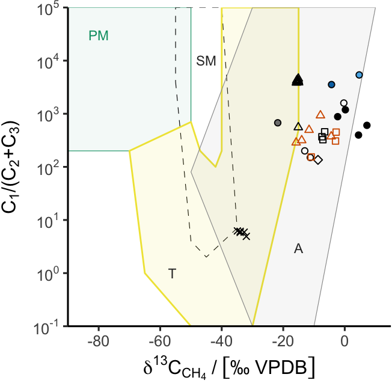

```r
# Set coordinates of fields of origins (Milkov and Etiope 2018)
primary_microbial_bernard <- data.frame(
  x = c(-90,-70,-50, -50, -90),
  y = c(2e2,2e2,7e2, 1e5, 1e5)
)

secondary_microbial_bernard <- data.frame(
  x = c(-55, -50, -45, -35, -40, -55),
  y = c(4e3, 4e0, 2e0, 7e0, 1e5, 1e5)
)

thermogenic_bernard <- data.frame(
  x = c(-50, -65, -70, -50, -47, -42, -40, -40, -15, -15, -30, -50),
  y = c(1e-1, 1e0, 2e2, 7e2, 2e2, 1e2, 2e2, 1e5, 1e5, 5e2, 1e-1, 1e-1)
)

abiotic_bernard <- data.frame(
  x = c(-50, -30, -10, 10, -30),
  y = c(8e1, 1e-1, 1e-1, 1e5, 1e5)
)

# create plot
C1_C2_C3_plot <-
  ggplot() +

  # add origin fields
  geom_polygon(data = primary_microbial_bernard, aes(x=x, y=y), fill = microbial_color, alpha = microbial_opacity, color = microbial_color, size = 0.2) +
  geom_polygon(data = secondary_microbial_bernard, aes(x=x, y=y), fill = NA, color = "black", size = 0.2, linetype = "dashed") +
  geom_polygon(data = thermogenic_bernard, aes(x=x, y=y), alpha = thermo_opacity, fill = thermogenic_color, color = thermogenic_color, size = 0.5) +
  geom_polygon(data = abiotic_bernard, aes(x=x, y=y), alpha= abiotic_opacity, fill = abiotic_color, color = abiotic_color, size = .2) +

  # add text annotations
  annotate("text", y = 3e4, x = -80, size = 3, label = "PM", color = microbial_color) +
  annotate("text", y = 1e4, x = -45, size = 3, label = "SM", color = "grey20") +
  annotate("text", y = 1e0, x = -56, size = 3, label = "T", color = "grey20") +
  annotate("text", y = 3e0, x = -15, size = 3, label = "A", color = "grey20") +

  # plot literature data
  geom_point(data = data_C1_C2_C3_lit,
    aes(
    x = CH4_d13C_permil_VPDB,
    y = C1_over_C2_plus_C3,
    shape = site,
    color = sample_type,
    ), alpha = 1) +

  # plot Oman well data
  geom_point(data = data_C1_C2_C3,
    aes(
    x = CH4_d13C_permil_VPDB_CUB ,
    y = C1_over_C2_plus_C3,
    shape = site,
    fill = sampling_site
    ), alpha = 1) +

  # axis styling
  scale_y_continuous(trans = 'log10',
    breaks = trans_breaks('log10', function(x) 10 ^ x, n=5),
    labels = trans_format('log10', math_format(10^.x)),
    limits = c(.1, 1e5), expand = c(0,0),
    name = latex2exp::TeX("$C_1$/($C_{2}$+$C_{3}$)"))+
    scale_x_continuous(name = latex2exp::TeX("$\\delta ^{13}C_{CH_4}$$\\,$/$\\,$$\\lbrack$‰ VPDB$\\rbrack$"), limits = c(-90, 15), expand = c(0,0)) +

  # symbol styling
  scale_shape_manual(values = shapes_all_sites_named) +
  scale_color_manual(values = color_rock_crush_named) +
  scale_fill_manual(values = fill_4_wells_named, name = "water type", guide = guide_legend(order = 2)) +

  # design
  theme_classic(base_size = 12)+
  theme(
    # axis.title.x = element_blank(),
    # axis.text.x.bottom = element_blank(),
    # axis.ticks.x.bottom = element_blank(),
    # axis.line.x.bottom = element_blank(),
    plot.margin = margin(5, 1, 5, 1, "pt"),
    legend.position = "none"
    )

# print plot
C1_C2_C3_plot
```

# 3 Alkanes $\delta^{13}$C plot

## 3.1 Prepare data

```r
# create data frame of CH4, C2H6, and C3H8 d13C data
data_alkanes_d13C <- data %>% filter(!is.na(C2H6_d13C_permil_VPDB)) %>% select(sampling_site, year_sampled, depth_fluid_intake_mbct, CH4_d13C_permil_VPDB_CUB, CH4_d13C_unc_permil_CUB, CH4_d13C_permil_VPDB_MIT, CH4_d13C_unc_permil_MIT, CH4_d13C_permil_VPDB_ISOTECH, CH4_d13C_unc_permil_ISOTECH, C2H6_d13C_permil_VPDB, C2H6_d13C_unc_permil, C3H8_d13C_permil_VPDB, C3H8_d13C_unc_permil)

# print
data_alkanes_d13C
```

| sampling_site | year_sampled | depth_fluid_intake_mbct | CH4_d13C_permil_VPDB_CUB | CH4_d13C_unc_permil_CUB | CH4_d13C_permil_VPDB_MIT | CH4_d13C_unc_permil_MIT | CH4_d13C_permil_VPDB_ISOTECH | CH4_d13C_unc_permil_ISOTECH | C2H6_d13C_permil_VPDB | C2H6_d13C_unc_permil | C3H8_d13C_permil_VPDB | C3H8_d13C_unc_permil |
| --- | --- | --- | --- | --- | --- | --- | --- | --- | --- | --- | --- | --- |
| NSHQ14 | 2019 | 85 | 7.210306 | 0.7 | NA | NA | 6.5 | 0.3 | -5.543207 | 0.6 | 4.9 | 0.6 |
| NSHQ14 | 2017 | 85 | 0.200000 | 0.6 | -0.08 | 0.05 | NA | NA | -6.000000 | 0.6 | 3.3 | 0.6 |

Gather alkane $\delta^{13}\text{C}$ data so it can be plotted

```r
# gather data making a column for the compound
data_alkanes_d13C_gathered <- data_alkanes_d13C  %>% select(-depth_fluid_intake_mbct) %>% gather("compound_lab", "d13C_permil_VPDB", -sampling_site, -year_sampled, -CH4_d13C_unc_permil_CUB, -CH4_d13C_unc_permil_MIT, -CH4_d13C_unc_permil_ISOTECH, -C2H6_d13C_unc_permil, -C3H8_d13C_unc_permil)

# make a column that gives the # of C atoms in the compound based on the compounds chemcal formula
data_alkanes_d13C_gathered  <- data_alkanes_d13C_gathered %>% mutate(C_atoms = case_when(
str_detect(compound_lab, "CH") == TRUE ~ 1,
str_detect(compound_lab, "C2") == TRUE ~ 2,
str_detect(compound_lab, "C3") == TRUE ~ 3
))

# make another column for the uncertainty of each d13C analysis
data_alkanes_d13C_gathered  <- data_alkanes_d13C_gathered %>% mutate(uncertainty_d13C_permil = case_when(
compound_lab == "CH4_d13C_permil_VPDB_CUB" ~ CH4_d13C_unc_permil_CUB,
compound_lab == "CH4_d13C_permil_VPDB_MIT" ~ CH4_d13C_unc_permil_MIT,
compound_lab == "CH4_d13C_permil_VPDB_ISOTECH" ~ CH4_d13C_unc_permil_ISOTECH,
compound_lab == "C2H6_d13C_permil_VPDB" ~ C2H6_d13C_unc_permil,
compound_lab == "C3H8_d13C_permil_VPDB" ~ C3H8_d13C_unc_permil
))

# select only the most relevant columns
data_alkanes_d13C_gathered <- data_alkanes_d13C_gathered %>% select(sampling_site, year_sampled, C_atoms, compound_lab, d13C_permil_VPDB, uncertainty_d13C_permil) %>% filter(!is.na(d13C_permil_VPDB))

# print
data_alkanes_d13C_gathered
```

| sampling_site | year_sampled | C_atoms | compound_lab | d13C_permil_VPDB | uncertainty_d13C_permil |
| --- | --- | --- | --- | --- | --- |
| NSHQ14 | 2019 | 1 | CH4_d13C_permil_VPDB_CUB | 7.210306 | 0.70 |
| NSHQ14 | 2017 | 1 | CH4_d13C_permil_VPDB_CUB | 0.200000 | 0.60 |
| NSHQ14 | 2017 | 1 | CH4_d13C_permil_VPDB_MIT | -0.080000 | 0.05 |
| NSHQ14 | 2019 | 1 | CH4_d13C_permil_VPDB_ISOTECH | 6.500000 | 0.30 |
| NSHQ14 | 2019 | 2 | C2H6_d13C_permil_VPDB | -5.543207 | 0.60 |
| NSHQ14 | 2017 | 2 | C2H6_d13C_permil_VPDB | -6.000000 | 0.60 |
| NSHQ14 | 2019 | 3 | C3H8_d13C_permil_VPDB | 4.900000 | 0.60 |
| NSHQ14 | 2017 | 3 | C3H8_d13C_permil_VPDB | 3.300000 | 0.60 |

Add a site and sample type to Oman well data so that it is compatible for plotting with literature data

```r
data_alkanes_d13C_gathered <- data_alkanes_d13C_gathered %>% mutate(site = "Oman/UAE", sample_type = "vent/well\nfluid")

data_alkanes_d13C_gathered
```

| sampling_site | year_sampled | C_atoms | compound_lab | d13C_permil_VPDB | uncertainty_d13C_permil | site | sample_type |
| --- | --- | --- | --- | --- | --- | --- | --- |
| NSHQ14 | 2019 | 1 | CH4_d13C_permil_VPDB_CUB | 7.210306 | 0.70 | Oman/UAE | vent/well\nfluid |
| NSHQ14 | 2017 | 1 | CH4_d13C_permil_VPDB_CUB | 0.200000 | 0.60 | Oman/UAE | vent/well\nfluid |
| NSHQ14 | 2017 | 1 | CH4_d13C_permil_VPDB_MIT | -0.080000 | 0.05 | Oman/UAE | vent/well\nfluid |
| NSHQ14 | 2019 | 1 | CH4_d13C_permil_VPDB_ISOTECH | 6.500000 | 0.30 | Oman/UAE | vent/well\nfluid |
| NSHQ14 | 2019 | 2 | C2H6_d13C_permil_VPDB | -5.543207 | 0.60 | Oman/UAE | vent/well\nfluid |
| NSHQ14 | 2017 | 2 | C2H6_d13C_permil_VPDB | -6.000000 | 0.60 | Oman/UAE | vent/well\nfluid |
| NSHQ14 | 2019 | 3 | C3H8_d13C_permil_VPDB | 4.900000 | 0.60 | Oman/UAE | vent/well\nfluid |
| NSHQ14 | 2017 | 3 | C3H8_d13C_permil_VPDB | 3.300000 | 0.60 | Oman/UAE | vent/well\nfluid |

Get literature data

```r
# get relevant data for C1-C5 alkane analyses
data_alkanes_d13C_lit <- data_literature %>% filter(!is.na(C2H6_d13C_permil_VPDB)) %>% filter(!is.na(C2H6_d13C_permil_VPDB)) %>% select(site, Sample, sample_type, CH4_d13C_permil_VPDB, C2H6_d13C_permil_VPDB, C3H8_d13C_permil_VPDB,  n_C4H10_d13C_permil_VPDB, n_C5H12_d13C_permil_VPDB)

# print
data_alkanes_d13C_lit
```

| site | Sample | sample_type | CH4_d13C_permil_VPDB | C2H6_d13C_permil_VPDB | C3H8_d13C_permil_VPDB | n_C4H10_d13C_permil_VPDB | n_C5H12_d13C_permil_VPDB |
| --- | --- | --- | --- | --- | --- | --- | --- |
| Ashadze II | NA | vent/well fluid | -8.7 | -2.0 | 8.3 | 10.0 | NA |
| Oman/UAE | 1b | vent/well fluid | -12.0 | -11.4 | NA | NA | NA |
| Philippines | NSS-02 | rock crushing | -3.0 | -0.9 | NA | NA | NA |
| Philippines | NSS-04 | rock crushing | -2.8 | -1.2 | NA | NA | NA |
| Mid-Cayman Rise | ALV 620-3C | rock crushing | -14.0 | -12.5 | NA | NA | NA |
| Mid-Cayman Rise | ALV 620-5-1 | rock crushing | -4.4 | 0.7 | NA | NA | NA |
| Mid-Cayman Rise | ALV 621-3-1 | rock crushing | -7.9 | -10.6 | NA | NA | NA |
| Mid-Cayman Rise | J2-612-IGT2 | vent/well fluid | -15.6 | -12.9 | -9.8 | NA | NA |
| Mid-Cayman Rise | J2-616-IGT8 | vent/well fluid | -15.3 | -12.3 | NA | NA | NA |
| Mid-Cayman Rise | J2-617-IGT4 | vent/well fluid | -15.8 | -13.2 | -10.8 | NA | NA |

[output cut: 24 more lines]

As previously done for Oman well data, gather literature data by compound for plotting purposes

```r
# select most relevant data from literature
data_alkanes_d13C_lit <- data_alkanes_d13C_lit %>%  select(site, Sample, sample_type, CH4_d13C_permil_VPDB, C2H6_d13C_permil_VPDB, C3H8_d13C_permil_VPDB,  n_C4H10_d13C_permil_VPDB, n_C5H12_d13C_permil_VPDB)

# gather by compound
data_alkanes_d13C_gathered_lit <- data_alkanes_d13C_lit %>% gather("compound", "d13C_permil_VPDB", -site, -Sample, -sample_type)

# assign number of C atoms per molecule based on the compound formula
data_alkanes_d13C_gathered_lit <- data_alkanes_d13C_gathered_lit %>% mutate(C_atoms = case_when(
str_detect(compound, "CH4") == TRUE ~ 1,
str_detect(compound, "C2H6") == TRUE ~ 2,
str_detect(compound, "C3H8") == TRUE ~ 3,
str_detect(compound, "C4H10") == TRUE ~ 4,
str_detect(compound, "C5H12") == TRUE ~ 5
))

# change sample type to have new line character for plotting
data_alkanes_d13C_gathered_lit  <- data_alkanes_d13C_gathered_lit %>% mutate(sample_type = if_else(sample_type == "vent/well fluid", "vent/well\nfluid", "rock\ncrushing"))

# print
data_alkanes_d13C_gathered_lit
```

| site | Sample | sample_type | compound | d13C_permil_VPDB | C_atoms |
| --- | --- | --- | --- | --- | --- |
| Ashadze II | NA | vent/well\nfluid | CH4_d13C_permil_VPDB | -8.7 | 1 |
| Oman/UAE | 1b | vent/well\nfluid | CH4_d13C_permil_VPDB | -12.0 | 1 |
| Philippines | NSS-02 | rock\ncrushing | CH4_d13C_permil_VPDB | -3.0 | 1 |
| Philippines | NSS-04 | rock\ncrushing | CH4_d13C_permil_VPDB | -2.8 | 1 |
| Mid-Cayman Rise | ALV 620-3C | rock\ncrushing | CH4_d13C_permil_VPDB | -14.0 | 1 |
| Mid-Cayman Rise | ALV 620-5-1 | rock\ncrushing | CH4_d13C_permil_VPDB | -4.4 | 1 |
| Mid-Cayman Rise | ALV 621-3-1 | rock\ncrushing | CH4_d13C_permil_VPDB | -7.9 | 1 |
| Mid-Cayman Rise | J2-612-IGT2 | vent/well\nfluid | CH4_d13C_permil_VPDB | -15.6 | 1 |
| Mid-Cayman Rise | J2-616-IGT8 | vent/well\nfluid | CH4_d13C_permil_VPDB | -15.3 | 1 |
| Mid-Cayman Rise | J2-617-IGT4 | vent/well\nfluid | CH4_d13C_permil_VPDB | -15.8 | 1 |

[output cut: 160 more lines]

## 3.2 Plot

### 3.2.1 Plot data

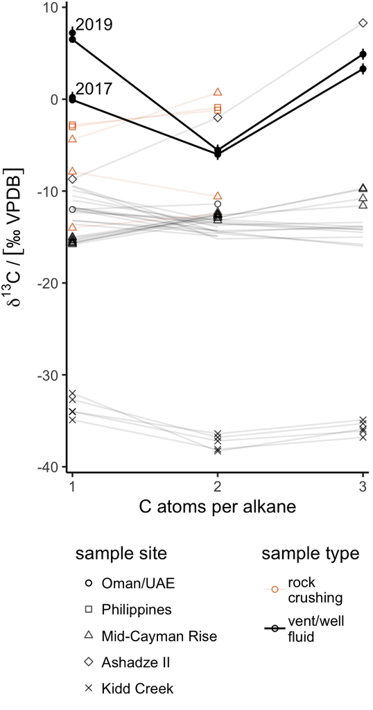

```r
# create plot
alkanes_d13C_oman_wells_and_lit_plot <- ggplot() +

  # Add NSHQ14 label
  annotate("text", label = "2017", x = 1.15, y = 1.2, label.size = 0.22) +
  annotate("text", label = "2019", x = 1.15, y = 8.2, label.size = 0.22) +

  # Plot literature data
  # lines
  geom_line(data = data_alkanes_d13C_gathered_lit %>% filter(C_atoms < 4),
    mapping =  aes(
    x = C_atoms,
    y = d13C_permil_VPDB,
    color = sample_type,
    group = Sample), alpha = 0.1) +

  # points
  geom_point(data = data_alkanes_d13C_gathered_lit %>% filter(C_atoms < 4),
    mapping =  aes(
    x = C_atoms,
    y = d13C_permil_VPDB,
    shape = site,
    color = sample_type), alpha = 0.7) +

  # Plot Oman well data
  # lines
  geom_line(data = data_alkanes_d13C_gathered %>% filter(C_atoms < 4),
    mapping =  aes(
    x = C_atoms,
    y = d13C_permil_VPDB,
    group = year_sampled,
    color = sample_type), alpha = 1, size = .6) +

  # error bars
  geom_linerange(data = data_alkanes_d13C_gathered,
    mapping =  aes(
    x = C_atoms,
    ymax = d13C_permil_VPDB + uncertainty_d13C_permil,
    ymin = d13C_permil_VPDB - uncertainty_d13C_permil,
    color = sample_type), show.legend = FALSE) +
  # points
  geom_point(data = data_alkanes_d13C_gathered,
    mapping =  aes(
    x = C_atoms,
    y = d13C_permil_VPDB,
    shape = site,
    color = sample_type,
    fill = sampling_site)) +

  # symbol styling
  scale_shape_manual(name = "sample site",  values = shapes_all_sites_named, guide = guide_legend(order = 1)) +
    scale_fill_manual(values = fill_4_wells_named, guide = FALSE) +
    scale_color_manual(values =  color_rock_crush_named_new_line, name = "sample type", guide = guide_legend(nrow = 1, order = 3)) +
    guides(color = guide_legend(override.aes=list(shape=21))) +

  # axis styling
  scale_x_continuous(name = "C atoms per alkane", breaks = c(1,2,3), expand = expand_scale(add = c(0.04)))+
  scale_y_continuous(name = latex2exp::TeX("$\\delta ^{13}C$$\\,$/$\\,$\\lbrack$$‰ VPDB$\\rbrack$"))+

  # design
  theme_classic(base_size = 12) +
  theme(
    panel.grid.major.x = element_blank(),
    panel.grid.minor.x = element_blank(),
    panel.grid.major.y = element_blank(),
    panel.grid.minor.y = element_blank(),
    legend.direction = "vertical",
    legend.position = "bottom",
    legend.text = element_text(margin = margin(t=3, b=3)),
    plot.margin = margin(1, 3, 0, 1, "pt")
    )

# print plot
alkanes_d13C_oman_wells_and_lit_plot
```

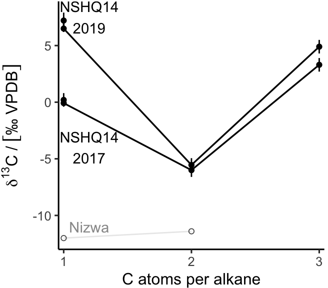

```r
# create plot
alkanes_d13C_oman_only_plot <- ggplot() +

  # Add NSHQ14 label
  annotate("text", label = "NSHQ14\n2017", x = 1.2, y = -4, label.size = 0.22, hjust = 0.5) +
  annotate("text", label = "NSHQ14\n2019", x = 1.2, y = 7.5, label.size = 0.22, hjust = 0.5) +

    # Add Nizwa label
  annotate("text", label = "Nizwa", x = 1.2, y = -11, label.size = 0.22, hjust = 0.5, color = "#999999") +

  # Plot literature data
  # lines
  geom_line(data = data_alkanes_d13C_gathered_lit %>% filter(C_atoms < 4) %>% filter(site == "Oman/UAE"),
    mapping =  aes(
    x = C_atoms,
    y = d13C_permil_VPDB,
    color = sample_type,
    group = Sample), alpha = 0.1) +

  # points
  geom_point(data = data_alkanes_d13C_gathered_lit %>% filter(C_atoms < 4) %>% filter(site == "Oman/UAE"),
    mapping =  aes(
    x = C_atoms,
    y = d13C_permil_VPDB,
    shape = site,
    color = sample_type), alpha = 0.7) +

  # Plot Oman well data
  # lines
  geom_line(data = data_alkanes_d13C_gathered %>% filter(C_atoms < 4),
    mapping =  aes(
    x = C_atoms,
    y = d13C_permil_VPDB,
    group = year_sampled,
    color = sample_type), alpha = 1, size = .6) +

  # error bars
  geom_linerange(data = data_alkanes_d13C_gathered,
    mapping =  aes(
    x = C_atoms,
    ymax = d13C_permil_VPDB + uncertainty_d13C_permil,
    ymin = d13C_permil_VPDB - uncertainty_d13C_permil,
    color = sample_type), show.legend = FALSE) +
  # points
  geom_point(data = data_alkanes_d13C_gathered,
    mapping =  aes(
    x = C_atoms,
    y = d13C_permil_VPDB,
    shape = site,
    color = sample_type,
    fill = sampling_site)) +

  # symbol styling
  scale_shape_manual(name = "sample site",  values = shapes_all_sites_named, guide = guide_legend(order = 1)) +
    scale_fill_manual(values = fill_4_wells_named, guide = FALSE) +
    scale_color_manual(values =  color_rock_crush_named_new_line, name = "sample type", guide = guide_legend(nrow = 1, order = 3)) +
    guides(color = guide_legend(override.aes=list(shape=21))) +

  # axis styling
  scale_x_continuous(name = "C atoms per alkane", breaks = c(1,2,3), expand = expand_scale(add = c(0.04)))+
  scale_y_continuous(name = latex2exp::TeX("$\\delta ^{13}C$$\\,$/$\\,$\\lbrack$$‰ VPDB$\\rbrack$"))+

  # design
  theme_classic(base_size = 12) +
  theme(
    panel.grid.major.x = element_blank(),
    panel.grid.minor.x = element_blank(),
    panel.grid.major.y = element_blank(),
    panel.grid.minor.y = element_blank(),
    legend.direction = "vertical",
    legend.position = "none",
    legend.text = element_text(margin = margin(t=3, b=3)),
    plot.margin = margin(1, 3, 0, 1, "pt")
    )

# print plot
alkanes_d13C_oman_only_plot
```

# 4 CH$_4$ Fraction modern facet grid plot

## 4.1 Prepare data

```r
# create data frame of CH4, C2H6, and C3H8 d13C data
data_14CH4 <- data %>% filter(!is.na(CH4_Fm_UCIAMS)) %>% select(sampling_site, year_sampled, notes, CH4_Fm_UCIAMS, CH4_Fm_unc_UCIAMS, CH4_Fm_NOSAMS, CH4_Fm_unc_NOSAMS, CH4_d13C_permil_VPDB_CUB, CH4_d13C_unc_permil_CUB, CH4_d13C_permil_VPDB_ISOTECH, CH4_d13C_unc_permil_ISOTECH, CH4_dD_permil_VSMOW_CUB, CH4_dD_unc_permil_CUB)

# print
data_14CH4
```

| sampling_site | year_sampled | notes | CH4_Fm_UCIAMS | CH4_Fm_unc_UCIAMS | CH4_Fm_NOSAMS | CH4_Fm_unc_NOSAMS | CH4_d13C_permil_VPDB_CUB | CH4_d13C_unc_permil_CUB | CH4_d13C_permil_VPDB_ISOTECH | CH4_d13C_unc_permil_ISOTECH | CH4_dD_permil_VSMOW_CUB | CH4_dD_unc_permil_CUB |
| --- | --- | --- | --- | --- | --- | --- | --- | --- | --- | --- | --- | --- |
| NSHQ14 | 2019 | NA | 0.0566 | 0.0006 | 0.0614 | 0.0014 | 7.210306 | 0.7 | 6.5 | 0.3 | -263.1138 | 5 |
| NSHQ14 | 2019 | no purge (NP) | 0.0497 | 0.0006 | NA | NA | 4.475894 | 0.7 | NA | NA | -250.6066 | 5 |
| WAB71 | 2019 | Water was intermittently clear and highly sediment-rich. Particulate filters loaded with much sediment. | 0.0050 | 0.0001 | NA | NA | 7.037230 | 0.7 | NA | NA | -303.8653 | 5 |
| CM2A | 2018 | NA | 0.0002 | 0.0011 | NA | NA | -4.300000 | 0.6 | NA | NA | -206.0000 | 6 |
| NSHQ04 | 2018 | NA | 0.0069 | 0.0010 | NA | NA | 4.700000 | 0.6 | NA | NA | -229.0000 | 6 |
| NSHQ14 | 2018 | NA | 0.3038 | 0.0015 | NA | NA | -2.300000 | 0.6 | NA | NA | -314.0000 | 8 |
| WAB71 | 2018 | NA | -0.0020 | 0.0000 | NA | NA | 3.600000 | 0.6 | NA | NA | -307.0000 | 8 |
| NSHQ14 | 2017 | NA | 0.1918 | 0.0010 | NA | NA | 0.200000 | 0.6 | NA | NA | -271.0000 | 7 |

```r
(data_14CH4_NSHQ14 <- data_14CH4 %>% filter(sampling_site == "NSHQ14"))
```

| sampling_site | year_sampled | notes | CH4_Fm_UCIAMS | CH4_Fm_unc_UCIAMS | CH4_Fm_NOSAMS | CH4_Fm_unc_NOSAMS | CH4_d13C_permil_VPDB_CUB | CH4_d13C_unc_permil_CUB | CH4_d13C_permil_VPDB_ISOTECH | CH4_d13C_unc_permil_ISOTECH | CH4_dD_permil_VSMOW_CUB | CH4_dD_unc_permil_CUB |
| --- | --- | --- | --- | --- | --- | --- | --- | --- | --- | --- | --- | --- |
| NSHQ14 | 2019 | NA | 0.0566 | 0.0006 | 0.0614 | 0.0014 | 7.210306 | 0.7 | 6.5 | 0.3 | -263.1138 | 5 |
| NSHQ14 | 2019 | no purge (NP) | 0.0497 | 0.0006 | NA | NA | 4.475894 | 0.7 | NA | NA | -250.6066 | 5 |
| NSHQ14 | 2018 | NA | 0.3038 | 0.0015 | NA | NA | -2.300000 | 0.6 | NA | NA | -314.0000 | 8 |
| NSHQ14 | 2017 | NA | 0.1918 | 0.0010 | NA | NA | 0.200000 | 0.6 | NA | NA | -271.0000 | 7 |

```r
data_14CH4_NSHQ14_longer <- data_14CH4_NSHQ14 %>%
  # combine F14C data from different labs: UCIAMS and NOSAMS
  pivot_longer(c(CH4_Fm_UCIAMS, CH4_Fm_NOSAMS), names_to = "parameter", values_to = "CH4_Fm", values_drop_na = TRUE) %>%
  # rename "parameter" column (e.g. "CH4_Fm_UCIAMS") to the laboratory name
  mutate(lab = case_when(
str_detect(parameter, "UCIAMS") == TRUE ~ "CUB/UCI",
str_detect(parameter, "NOSAMS") == TRUE ~ "Isotech/\nNOSAMS"
))  %>%
  # drop "parameter column
  select(-parameter) %>%
  # assign Fm uncertainties based on lab
  mutate(CH4_Fm_unc = if_else(lab == "Isotech/\nNOSAMS", CH4_Fm_unc_NOSAMS, CH4_Fm_unc_UCIAMS)) %>%
  select(-CH4_Fm_unc_NOSAMS, -CH4_Fm_unc_UCIAMS) %>%
  # relocate lab column after CH4_Fm_unc_UCIAMS
  relocate(lab, .before = CH4_Fm) %>%
  # assign CH4 d13C based on lab
  mutate(CH4_d13C_permil_VPDB = if_else(lab == "Isotech/\nNOSAMS", CH4_d13C_permil_VPDB_ISOTECH, CH4_d13C_permil_VPDB_CUB)) %>%
  select(-CH4_d13C_permil_VPDB_ISOTECH, -CH4_d13C_permil_VPDB_CUB) %>%
  # assign CH4 d13C uncertainty based on lab
  mutate(CH4_d13C_unc_permil = if_else(lab == "Isotech/\nNOSAMS", CH4_d13C_unc_permil_ISOTECH, CH4_d13C_unc_permil_CUB)) %>%
  select(-CH4_d13C_unc_permil_ISOTECH, -CH4_d13C_unc_permil_CUB) %>%
  # assign CH4 dD based on lab (CH4 dD was not measured by Isotech)
  mutate(CH4_dD_permil_VSMOW = if_else(lab == "Isotech/\nNOSAMS", NA_real_, CH4_dD_permil_VSMOW_CUB)) %>%
  select(-CH4_dD_permil_VSMOW_CUB) %>%
  # assign CH4 dD uncertainty based on lab
  mutate(CH4_dD_unc_permil = if_else(lab == "Isotech/\nNOSAMS", NA_real_, CH4_dD_unc_permil_CUB)) %>%
  select(-CH4_dD_unc_permil_CUB)

data_14CH4_NSHQ14_longer
```

| sampling_site | year_sampled | notes | lab | CH4_Fm | CH4_Fm_unc | CH4_d13C_permil_VPDB | CH4_d13C_unc_permil | CH4_dD_permil_VSMOW | CH4_dD_unc_permil |
| --- | --- | --- | --- | --- | --- | --- | --- | --- | --- |
| NSHQ14 | 2019 | NA | CUB/UCI | 0.0566 | 0.0006 | 7.210306 | 0.7 | -263.1138 | 5 |
| NSHQ14 | 2019 | NA | Isotech/\nNOSAMS | 0.0614 | 0.0014 | 6.500000 | 0.3 | NA | NA |
| NSHQ14 | 2019 | no purge (NP) | CUB/UCI | 0.0497 | 0.0006 | 4.475894 | 0.7 | -250.6066 | 5 |
| NSHQ14 | 2018 | NA | CUB/UCI | 0.3038 | 0.0015 | -2.300000 | 0.6 | -314.0000 | 8 |
| NSHQ14 | 2017 | NA | CUB/UCI | 0.1918 | 0.0010 | 0.200000 | 0.6 | -271.0000 | 7 |

```r
data_14CH4_NSHQ14_longer_longer <- data_14CH4_NSHQ14_longer %>%
  pivot_longer(c(CH4_d13C_permil_VPDB, CH4_dD_permil_VSMOW), names_to = "parameter", values_to = "value") %>%
    # assign uncertainty based on parameter
  mutate(uncertainty_permil = if_else(parameter == "CH4_d13C_permil_VPDB", CH4_d13C_unc_permil, CH4_dD_unc_permil)) %>%
  select(-CH4_d13C_unc_permil, -CH4_dD_unc_permil)

data_14CH4_NSHQ14_longer_longer
```

| sampling_site | year_sampled | notes | lab | CH4_Fm | CH4_Fm_unc | parameter | value | uncertainty_permil |
| --- | --- | --- | --- | --- | --- | --- | --- | --- |
| NSHQ14 | 2019 | NA | CUB/UCI | 0.0566 | 0.0006 | CH4_d13C_permil_VPDB | 7.210306 | 0.7 |
| NSHQ14 | 2019 | NA | CUB/UCI | 0.0566 | 0.0006 | CH4_dD_permil_VSMOW | -263.113763 | 5.0 |
| NSHQ14 | 2019 | NA | Isotech/\nNOSAMS | 0.0614 | 0.0014 | CH4_d13C_permil_VPDB | 6.500000 | 0.3 |
| NSHQ14 | 2019 | NA | Isotech/\nNOSAMS | 0.0614 | 0.0014 | CH4_dD_permil_VSMOW | NA | NA |
| NSHQ14 | 2019 | no purge (NP) | CUB/UCI | 0.0497 | 0.0006 | CH4_d13C_permil_VPDB | 4.475894 | 0.7 |
| NSHQ14 | 2019 | no purge (NP) | CUB/UCI | 0.0497 | 0.0006 | CH4_dD_permil_VSMOW | -250.606586 | 5.0 |
| NSHQ14 | 2018 | NA | CUB/UCI | 0.3038 | 0.0015 | CH4_d13C_permil_VPDB | -2.300000 | 0.6 |
| NSHQ14 | 2018 | NA | CUB/UCI | 0.3038 | 0.0015 | CH4_dD_permil_VSMOW | -314.000000 | 8.0 |
| NSHQ14 | 2017 | NA | CUB/UCI | 0.1918 | 0.0010 | CH4_d13C_permil_VPDB | 0.200000 | 0.6 |
| NSHQ14 | 2017 | NA | CUB/UCI | 0.1918 | 0.0010 | CH4_dD_permil_VSMOW | -271.000000 | 7.0 |

```r
# add tex formatting
data_14CH4_NSHQ14_longer_longer  <- data_14CH4_NSHQ14_longer_longer  %>%
  mutate(
    tex_params = as_factor(parameter)%>%
      fct_recode(
        "$\\delta ^{13}C_{CH_4}\\,/\\,\\[$‰$  \\, VPDB \\]$" = "CH4_d13C_permil_VPDB",
                "$\\delta ^{2}H_{CH_4}\\,/\\,\\[$‰$  \\, VSMOW \\]$" = "CH4_dD_permil_VSMOW"
  )) %>%
  # make shorter note for NSHQ14
  mutate(notes_short = if_else(notes == "no purge (NP)", "NP", NA_character_))
```

## 4.2 Plot

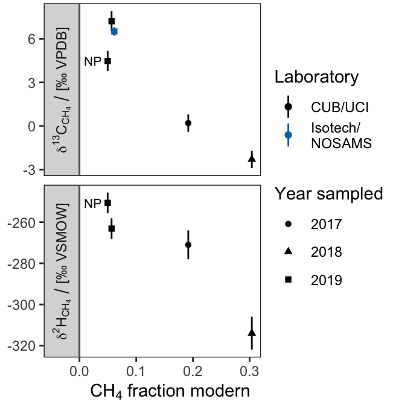

```r
CH4_F14C_d13C_dD_plot <- data_14CH4_NSHQ14_longer_longer %>% ggplot(aes(
  x = CH4_Fm,
  y = value,
  # x error bars are smaller than data points
  # xmin = CH4_Fm - CH4_Fm_unc,
  # xmax = CH4_Fm + CH4_Fm_unc,
  ymin = value - uncertainty_permil,
  ymax = value + uncertainty_permil,
  shape = as.character(year_sampled),
  color = lab,
  label = notes_short
)) +

  # error bars
  geom_linerange(orientation = "x") +
  # geom_linerange(orientation = "y") +

  # points
  geom_point() +

  # text
  geom_text(nudge_x = -0.026, size = 2.75, show.legend = FALSE) +

  # grid
  facet_grid(rows = vars(tex_params), scales = "free_y", switch = "y", labeller = latex_labeller) +

  # scale adjustments
  scale_x_continuous(name = latex2exp::TeX("CH$_4$ fraction modern"), limits = c(0, 0.32), expand = c(0,0)) +
  scale_y_continuous(name = NULL) +
  scale_shape_discrete(name = "Year sampled") +
  scale_color_manual(name = "Laboratory", values = c("CUB/UCI" = "black", "Isotech/\nNOSAMS" = "#0072B2")) +

  # styling
  theme_bw() +
  theme(
    panel.grid = element_blank(),
    legend.position = "right",
    legend.direction = "vertical",
    legend.box.margin = margin(r=2),
    plot.margin = margin(l=2, t=2, b=1, r=2),
    legend.box.spacing = unit(0.1, "cm")
  )

CH4_F14C_d13C_dD_plot
```

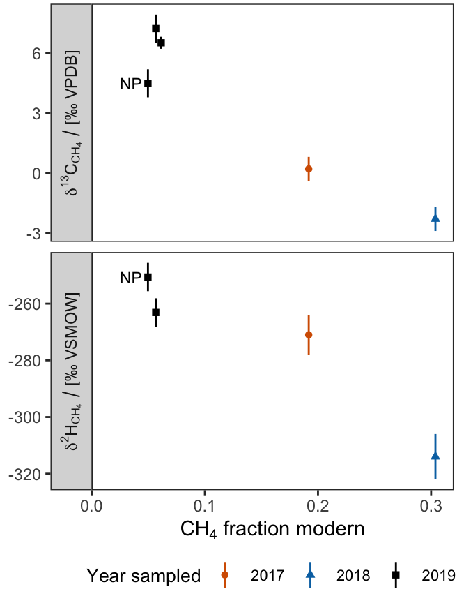

```r
CH4_F14C_d13C_dD_plot_year_color_shape <- data_14CH4_NSHQ14_longer_longer %>% ggplot(aes(
  x = CH4_Fm,
  y = value,
  # xmin = CH4_Fm - CH4_Fm_unc,
  # xmax = CH4_Fm + CH4_Fm_unc,
  ymin = value - uncertainty_permil,
  ymax = value + uncertainty_permil,
  shape = as.character(year_sampled),
  color = as.character(year_sampled),
  label = notes_short
)) +

  # error bars
  geom_linerange(orientation = "x") +
  # geom_linerange(orientation = "y") +

  # points
  geom_point() +

  # text
  geom_text(nudge_x = -0.015, size = 3, show.legend = FALSE) +

  # grid
  facet_grid(rows = vars(tex_params), scales = "free_y", switch = "y", labeller = latex_labeller) +

  # scale adjustments
  scale_x_continuous(name = latex2exp::TeX("CH$_4$ fraction modern"), limits = c(0, 0.32), expand = c(0,0)) +
  scale_y_continuous(name = NULL) +
  scale_shape_discrete(name = "Year sampled") +
  scale_color_manual(name = "Year sampled", values = cbPalette_MWL) +

  # styling
  theme_bw() +
  theme(
    panel.grid = element_blank(),
    legend.position = "bottom",
    legend.box.margin = margin(r=2),
    plot.margin = margin(l=2, t=2, b=1, r=2),
    legend.box.spacing = unit(0.1, "cm"),
    legend.text = element_text(size = 8.2),
    legend.title = element_text(size = 10)
  )

CH4_F14C_d13C_dD_plot_year_color_shape
```

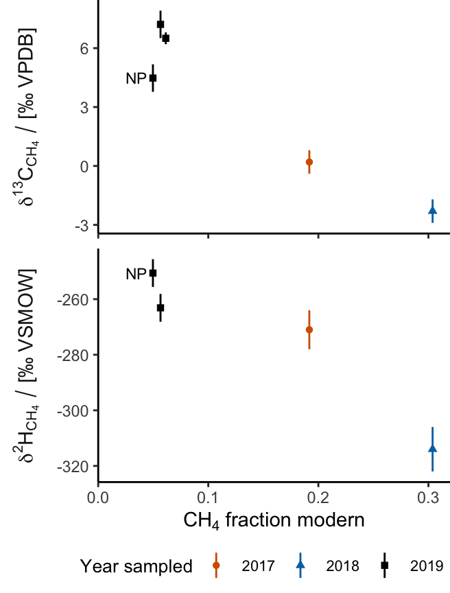

```r
CH4_F14C_d13C_dD_plot_year_color_shape_clean <- CH4_F14C_d13C_dD_plot_year_color_shape +
  facet_rep_grid(rows = vars(tex_params), scales = "free_y", switch = "y", labeller = latex_labeller) +
  theme_classic() +
  theme(
  strip.placement = "outside",
  strip.background = element_blank(),
  strip.text = element_text(size = 11, vjust = 0),
    legend.position = "bottom",
    legend.box.margin = margin(r=14),
    plot.margin = margin(l=0, t=0, b=1, r=0),
    legend.box.spacing = unit(0.1, "cm"),
    legend.text = element_text(size = 8.2),
    legend.title = element_text(size = 10)
)

CH4_F14C_d13C_dD_plot_year_color_shape_clean
```

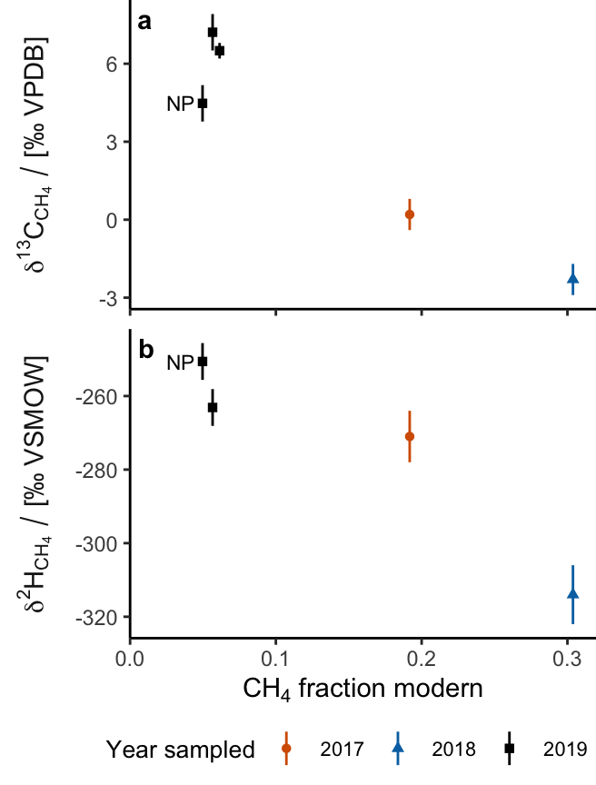

```r
CH4_F14C_d13C_dD_plot_year_color_shape_clean %>% tag_facet_keep_strip(
  open = "",
  close = "",
  tag_pool = letters
)
```

# 5 Correlations and regressions

## 5.1 $\delta^{13}\text{C}_{\text{CH}_4}$ vs. F$^{14}$C$_{\text{CH}_4}$

```r
cor.test( ~ CH4_Fm + CH4_d13C_permil_VPDB,
         data=data_14CH4_NSHQ14_longer,
         method = "pearson",
         conf.level = 0.95)
```

```
##
##  Pearson's product-moment correlation
##
## data:  CH4_Fm and CH4_d13C_permil_VPDB
## t = -5.4521, df = 3, p-value = 0.01212
## alternative hypothesis: true correlation is not equal to 0
## 95 percent confidence interval:
##  -0.9969981 -0.4448515
## sample estimates:
##        cor
## -0.9530624
```

```r
# generate linear model
model_d13C_F14C = lm(CH4_d13C_permil_VPDB ~ CH4_Fm,
           data = data_14CH4_NSHQ14_longer)

# print model summary
summary(model_d13C_F14C)
```

```
##
## Call:
## lm(formula = CH4_d13C_permil_VPDB ~ CH4_Fm, data = data_14CH4_NSHQ14_longer)
##
## Residuals:
##       1       2       3       4       5
##  1.3368  0.7942 -1.6385  0.4595 -0.9519
##
## Coefficients:
##             Estimate Std. Error t value Pr(>|t|)
## (Intercept)    7.850      1.066   7.363  0.00518 **
## CH4_Fm       -34.923      6.405  -5.452  0.01212 *
## ---
## Signif. codes:  0 '***' 0.001 '**' 0.01 '*' 0.05 '.' 0.1 ' ' 1
##
## Residual standard error: 1.44 on 3 degrees of freedom
## Multiple R-squared:  0.9083, Adjusted R-squared:  0.8778
## F-statistic: 29.73 on 1 and 3 DF,  p-value: 0.01212
```

Predict $\delta^{13}\text{C}_{\text{CH}_4}$ (and 95% confidence interval) for F$^{14}$C$_{\text{CH}_4}$ of 0 and 1

```r
predict(model_d13C_F14C, newdata = data.frame(CH4_Fm=c(0,1)), interval = c("confidence"))
```

```
##         fit        lwr       upr
## 1   7.85011   4.457081 11.243138
## 2 -27.07277 -44.871755 -9.273792
```

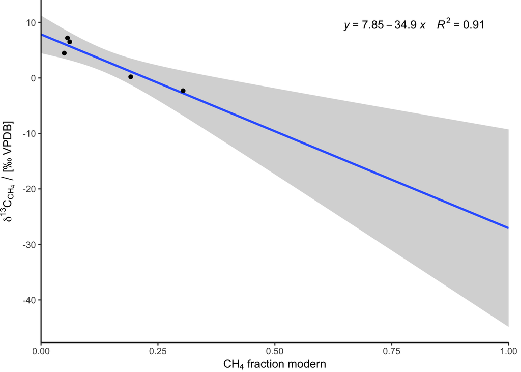

```r
data_14CH4_NSHQ14_longer %>% ggplot(aes(x = CH4_Fm, y = CH4_d13C_permil_VPDB))+
  geom_smooth(method = "lm", formula = y ~ x, fullrange = TRUE) +
  stat_poly_eq(formula =  y ~ x, parse = TRUE, aes(label =  paste(..eq.label.., ..rr.label.., sep = "~~~~")), label.x = "right") +
  geom_point()+
  scale_x_continuous(limits = c(0,1), expand = c(0,0), name = TeX("CH$_4$ fraction modern")) +
  scale_y_continuous(name = TeX("$\\delta ^{13}C_{CH_4}\\,/\\,\\[$‰$  \\, VPDB \\]$")) +
  theme_classic() +
  theme(
    plot.margin = margin(r = 12)
  )
```

## 5.2 $\delta\text{D}_{\text{CH}_4}$ vs. F$^{14}$C$_{\text{CH}_4}$

```r
cor.test( ~ CH4_Fm + CH4_dD_permil_VSMOW,
         data=data_14CH4_NSHQ14_longer,
         method = "pearson",
         conf.level = 0.95)
```

```
##
##  Pearson's product-moment correlation
##
## data:  CH4_Fm and CH4_dD_permil_VSMOW
## t = -3.7882, df = 2, p-value = 0.06316
## alternative hypothesis: true correlation is not equal to 0
## 95 percent confidence interval:
##  -0.9987068  0.2433714
## sample estimates:
##        cor
## -0.9368447
```

```r
# generate linear model
model_dD_F14C = lm(CH4_dD_permil_VSMOW ~ CH4_Fm,
           data = data_14CH4_NSHQ14_longer)

# print model summary
summary(model_dD_F14C)
```

```
##
## Call:
## lm(formula = CH4_dD_permil_VSMOW ~ CH4_Fm, data = data_14CH4_NSHQ14_longer)
##
## Residuals:
##      1      3      4      5
## -8.381  2.661 -6.741 12.461
##
## Coefficients:
##             Estimate Std. Error t value Pr(>|t|)
## (Intercept)  -242.71      10.30 -23.575  0.00179 **
## CH4_Fm       -212.48      56.09  -3.788  0.06316 .
## ---
## Signif. codes:  0 '***' 0.001 '**' 0.01 '*' 0.05 '.' 0.1 ' ' 1
##
## Residual standard error: 11.79 on 2 degrees of freedom
##   (1 observation deleted due to missingness)
## Multiple R-squared:  0.8777, Adjusted R-squared:  0.8165
## F-statistic: 14.35 on 1 and 2 DF,  p-value: 0.06316
```

```r
predict(model_dD_F14C, newdata = data.frame(CH4_Fm=c(0,1)), interval = c("confidence"))
```

```
##         fit       lwr       upr
## 1 -242.7067 -287.0036 -198.4098
## 2 -455.1897 -661.7777 -248.6018
```

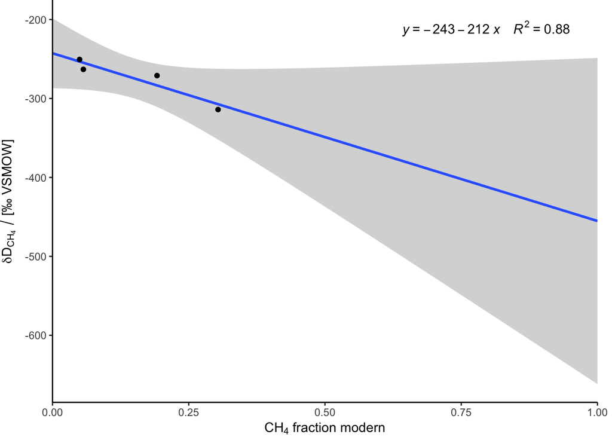

```r
data_14CH4_NSHQ14_longer %>% ggplot(aes(x = CH4_Fm, y = CH4_dD_permil_VSMOW))+
  geom_smooth(method = "lm", formula = y ~ x, fullrange = TRUE) +
  stat_poly_eq(formula =  y ~ x, parse = TRUE, aes(label =  paste(..eq.label.., ..rr.label.., sep = "~~~~")), label.x = "right") +
  geom_point()+
  scale_x_continuous(limits = c(0,1), expand = c(0,0), name = TeX("CH$_4$ fraction modern")) +
  scale_y_continuous(name = TeX("$\\delta D_{CH_4}\\,/\\,\\[$‰$  \\, VSMOW \\]$")) +
  theme_classic() +
  theme(
    plot.margin = margin(r = 12)
  )
```

## 5.3 $\delta\text{D}_{\text{CH}_4}$ vs. $\delta^{13}\text{C}_{\text{CH}_4}$

### 5.3.1 Only data from NSHQ14 with paired $\text{F}^{14}\text{C}_{\text{CH}_4}$ measurements

```r
cor.test( ~ CH4_d13C_permil_VPDB + CH4_dD_permil_VSMOW,
         data=data_14CH4_NSHQ14_longer,
         method = "pearson",
         conf.level = 0.95)
```

```
##
##  Pearson's product-moment correlation
##
## data:  CH4_d13C_permil_VPDB and CH4_dD_permil_VSMOW
## t = 1.9057, df = 2, p-value = 0.197
## alternative hypothesis: true correlation is not equal to 0
## 95 percent confidence interval:
##  -0.6925588  0.9956742
## sample estimates:
##       cor
## 0.8030376
```

```r
# generate linear model
model_dD_d13C = lm(CH4_dD_permil_VSMOW ~ CH4_d13C_permil_VPDB,
           data = data_14CH4_NSHQ14_longer)

# print model summary
summary(model_dD_d13C)
```

```
##
## Call:
## lm(formula = CH4_dD_permil_VSMOW ~ CH4_d13C_permil_VPDB, data = data_14CH4_NSHQ14_longer)
##
## Residuals:
##      1      3      4      5
## -13.43  13.28 -14.94  15.08
##
## Coefficients:
##                      Estimate Std. Error t value Pr(>|t|)
## (Intercept)          -287.122     11.980 -23.966  0.00174 **
## CH4_d13C_permil_VPDB    5.192      2.724   1.906  0.19696
## ---
## Signif. codes:  0 '***' 0.001 '**' 0.01 '*' 0.05 '.' 0.1 ' ' 1
##
## Residual standard error: 20.09 on 2 degrees of freedom
##   (1 observation deleted due to missingness)
## Multiple R-squared:  0.6449, Adjusted R-squared:  0.4673
## F-statistic: 3.632 on 1 and 2 DF,  p-value: 0.197
```

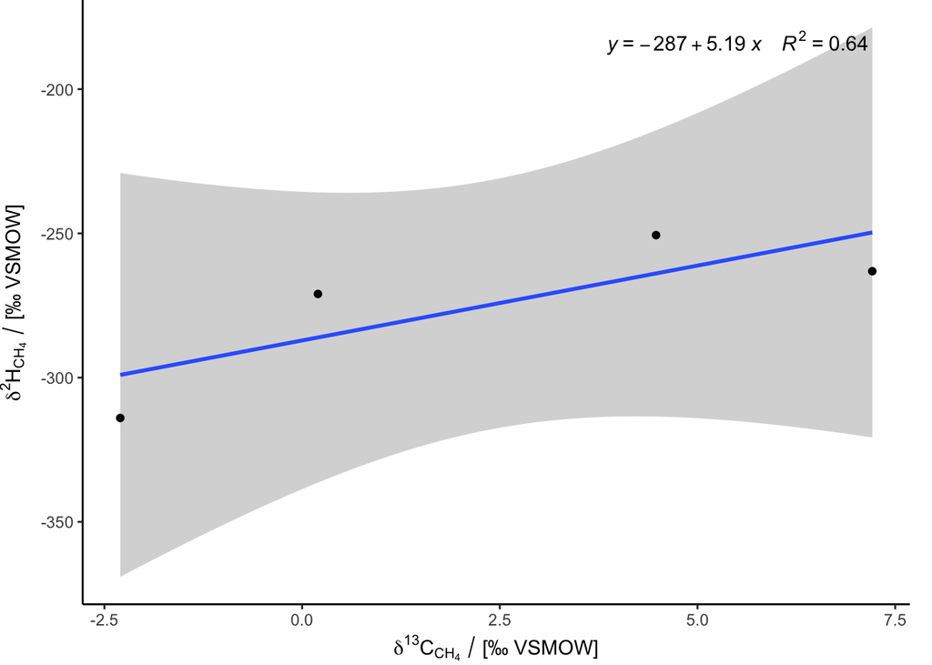

```r
data_14CH4_NSHQ14_longer %>% ggplot(aes(x = CH4_d13C_permil_VPDB, y = CH4_dD_permil_VSMOW))+
  geom_smooth(method = "lm", formula = y ~ x, fullrange = TRUE) +
  stat_poly_eq(formula =  y ~ x, parse = TRUE, aes(label =  paste(..eq.label.., ..rr.label.., sep = "~~~~")), label.x = "right") +
  geom_point()+
  scale_x_continuous(name = TeX("$\\delta ^{13}C_{CH_4}\\,/\\,\\[$‰$  \\, VSMOW \\]$")) +
  scale_y_continuous(name = TeX("$\\delta ^{2}H_{CH_4}\\,/\\,\\[$‰$  \\, VSMOW \\]$")) +
  theme_classic() +
  theme(
    plot.margin = margin(r = 12)
  )
```

### 5.3.2 All NSHQ14 data 2014-2019 data

Prepare Oman well data

```r
# make data frame of CH4 d13C and dD data for all wells
data_CD <- data %>% select(sampling_site, notes, year_sampled, depth_fluid_intake_mbct, water_type, CH4_d13C_permil_VPDB_LBNL, CH4_dD_permil_VSMOW_LBNL,
CH4_d13C_permil_VPDB_CUB, CH4_dD_permil_VSMOW_CUB, CH4_d13C_permil_VPDB_MIT, CH4_dD_permil_VSMOW_MIT, CH4_d13C_permil_VPDB_UCLA, CH4_dD_permil_VSMOW_UCLA, site)

# compute means between analyses in multiple labs
data_CD <- data_CD %>%
    rowwise() %>%
    mutate(CH4_d13C_permil_VPDB_interlab_mean  = mean(c(CH4_d13C_permil_VPDB_LBNL, CH4_d13C_permil_VPDB_CUB, CH4_d13C_permil_VPDB_MIT, CH4_d13C_permil_VPDB_UCLA), na.rm = TRUE))

data_CD <- data_CD %>%
    rowwise() %>%
    mutate(CH4_dD_permil_VSMOW_interlab_mean  = mean(c(CH4_dD_permil_VSMOW_LBNL, CH4_dD_permil_VSMOW_CUB, CH4_dD_permil_VSMOW_MIT, CH4_dD_permil_VSMOW_UCLA), na.rm = TRUE))

# remove samples without C and D isotope data
data_CD <- data_CD %>% filter(!is.nan(CH4_d13C_permil_VPDB_interlab_mean) & !is.nan(CH4_dD_permil_VSMOW_interlab_mean))

# print
data_CD %>% select(sampling_site, notes, year_sampled, CH4_d13C_permil_VPDB_interlab_mean, CH4_dD_permil_VSMOW_interlab_mean)
```

| sampling_site | notes | year_sampled | CH4_d13C_permil_VPDB_interlab_mean | CH4_dD_permil_VSMOW_interlab_mean |
| --- | --- | --- | --- | --- |
| NSHQ14 | NA | 2019 | 7.210306 | -263.1138 |
| NSHQ14 | no purge (NP) | 2019 | 4.475894 | -250.6066 |
| WAB56 | Pumped well down too far on Jan 12 (pumping 10:30 - 12:00 at 20 lpm), had to let recover and sample the next day. On Jan 13, first water muddy; water cleared up, but was highly gassy. | 2019 | -21.783920 | -346.6202 |
| WAB71 | Water was intermittently clear and highly sediment-rich. Particulate filters loaded with much sediment. | 2019 | 7.037230 | -303.8653 |
| CM2A | NA | 2018 | -4.280000 | -198.0167 |
| NSHQ04 | NA | 2018 | 4.438500 | -228.1980 |
| NSHQ14 | NA | 2018 | -3.557333 | -306.4367 |
| WAB71 | NA | 2018 | 3.600000 | -307.0000 |
| NSHQ04 | NA | 2017 | 5.195000 | -227.3350 |
| NSHQ14 | NA | 2017 | 0.060000 | -269.9100 |

[output cut: 5 more lines]

```r
# make data frame of CH4 d13C data
data_C_gathered <- data_CD %>% select(sampling_site, notes, year_sampled, water_type, CH4_d13C_permil_VPDB_CUB, CH4_d13C_permil_VPDB_MIT, CH4_d13C_permil_VPDB_UCLA, CH4_d13C_permil_VPDB_LBNL, site, depth_fluid_intake_mbct) %>%
  pivot_longer(cols = c(-sampling_site, -notes, -water_type, -year_sampled, -site, -depth_fluid_intake_mbct), names_to = "parameter", values_to = "CH4_d13C_permil_VPDB")

# make a column for analytical laboratory
data_C_gathered <- data_C_gathered %>% mutate(lab = case_when(
str_detect(parameter, "LBNL") == TRUE ~ "LBNL",
str_detect(parameter, "CUB") == TRUE ~ "CUB",
str_detect(parameter, "MIT") == TRUE ~ "MIT",
str_detect(parameter, "UCLA") == TRUE ~ "UCLA"
))  %>%
  select(-parameter)

# data_C_gathered

# repeat the above for dD
data_D_gathered <- data_CD %>% select(sampling_site, notes, water_type, year_sampled, CH4_dD_permil_VSMOW_CUB, CH4_dD_permil_VSMOW_MIT, CH4_dD_permil_VSMOW_UCLA, CH4_dD_permil_VSMOW_LBNL) %>%
  pivot_longer(cols = c(-sampling_site, -notes, -water_type, -year_sampled), names_to = "parameter", values_to = "CH4_dD_permil_VSMOW")

data_D_gathered <- data_D_gathered %>% mutate(lab = case_when(
str_detect(parameter, "LBNL") == TRUE ~ "LBNL",
str_detect(parameter, "CUB") == TRUE ~ "CUB",
str_detect(parameter, "MIT") == TRUE ~ "MIT",
str_detect(parameter, "UCLA") == TRUE ~ "UCLA"
))  %>%  select(-parameter)

# combine 13C and D data
data_CD_gathered <- full_join(data_C_gathered, data_D_gathered) %>%
  filter(!is.na(CH4_d13C_permil_VPDB) | !is.na(CH4_dD_permil_VSMOW))
```

[output not shown]

```r
data_CD_gathered_NSHQ14 <- data_CD_gathered %>%
  # only samples from NSHQ14
  filter(sampling_site == "NSHQ14") %>%
  # only samples with CH4 d13C and CH4 dD measurements
  filter(!is.na(CH4_d13C_permil_VPDB) & !is.na(CH4_dD_permil_VSMOW))

# print
data_CD_gathered_NSHQ14
```

| sampling_site | notes | year_sampled | water_type | site | depth_fluid_intake_mbct | CH4_d13C_permil_VPDB | lab | CH4_dD_permil_VSMOW |
| --- | --- | --- | --- | --- | --- | --- | --- | --- |
| NSHQ14 | NA | 2019 | Ca_OH | Oman/UAE | 85 | 7.210306 | CUB | -263.1138 |
| NSHQ14 | no purge (NP) | 2019 | Ca_OH | Oman/UAE | 85 | 4.475894 | CUB | -250.6066 |
| NSHQ14 | NA | 2018 | Ca_OH | Oman/UAE | 85 | -2.300000 | CUB | -314.0000 |
| NSHQ14 | NA | 2018 | Ca_OH | Oman/UAE | 85 | -5.020000 | MIT | -311.7300 |
| NSHQ14 | NA | 2018 | Ca_OH | Oman/UAE | 85 | -3.352000 | UCLA | -293.5800 |
| NSHQ14 | NA | 2017 | Ca_OH | Oman/UAE | 85 | 0.200000 | CUB | -271.0000 |
| NSHQ14 | NA | 2017 | Ca_OH | Oman/UAE | 85 | -0.080000 | MIT | -268.8200 |
| NSHQ14 | NA | 2016 | Ca_OH | Oman/UAE | 70 | -6.890000 | MIT | -308.5200 |
| NSHQ14 | NA | 2016 | Ca_OH | Oman/UAE | 70 | 1.800000 | LBNL | -273.0000 |
| NSHQ14 | NA | 2014 | Ca_OH | Oman/UAE | 262 | 3.000000 | LBNL | -232.0000 |

```r
# get sample size
data_CD_gathered_NSHQ14 %>% summarise(n = n())
```

| n |
| --- |
| 10 |

```r
cor.test( ~ CH4_d13C_permil_VPDB + CH4_dD_permil_VSMOW,
         data = data_CD_gathered_NSHQ14,
         method = "pearson",
         conf.level = 0.95)
```

```
##
##  Pearson's product-moment correlation
##
## data:  CH4_d13C_permil_VPDB and CH4_dD_permil_VSMOW
## t = 4.0233, df = 8, p-value = 0.003823
## alternative hypothesis: true correlation is not equal to 0
## 95 percent confidence interval:
##  0.3886158 0.9555266
## sample estimates:
##       cor
## 0.8180736
```

```r
# generate linear model
model_dD_d13C = lm(CH4_dD_permil_VSMOW ~ CH4_d13C_permil_VPDB,
           data = data_CD_gathered_NSHQ14)

# print model summary
summary(model_dD_d13C)
```

```
##
## Call:
## lm(formula = CH4_dD_permil_VSMOW ~ CH4_d13C_permil_VPDB, data = data_CD_gathered_NSHQ14)
##
## Residuals:
##     Min      1Q  Median      3Q     Max
## -24.029  -6.857   3.163   5.851  30.721
##
## Coefficients:
##                      Estimate Std. Error t value Pr(>|t|)
## (Intercept)          -278.146      5.323 -52.252 1.99e-11 ***
## CH4_d13C_permil_VPDB    5.142      1.278   4.023  0.00382 **
## ---
## Signif. codes:  0 '***' 0.001 '**' 0.01 '*' 0.05 '.' 0.1 ' ' 1
##
## Residual standard error: 16.83 on 8 degrees of freedom
## Multiple R-squared:  0.6692, Adjusted R-squared:  0.6279
## F-statistic: 16.19 on 1 and 8 DF,  p-value: 0.003823
```

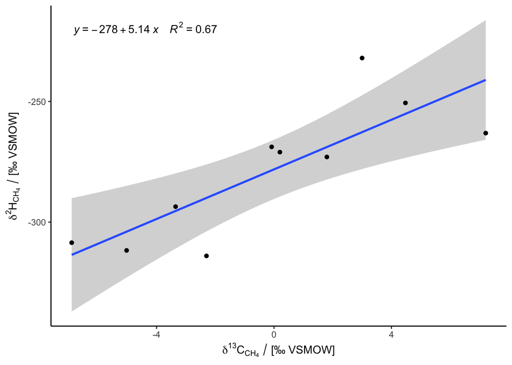

```r
data_CD_gathered_NSHQ14 %>% ggplot(aes(x = CH4_d13C_permil_VPDB, y = CH4_dD_permil_VSMOW))+
  geom_smooth(method = "lm", formula = y ~ x, fullrange = TRUE) +
  stat_poly_eq(formula =  y ~ x, parse = TRUE, aes(label =  paste(..eq.label.., ..rr.label.., sep = "~~~~"))) +
  geom_point()+
  scale_x_continuous(name = TeX("$\\delta ^{13}C_{CH_4}\\,/\\,\\[$‰$  \\, VSMOW \\]$")) +
  scale_y_continuous(name = TeX("$\\delta ^{2}H_{CH_4}\\,/\\,\\[$‰$  \\, VSMOW \\]$")) +
  theme_classic()
```

# 6 $\alpha_{\text{methane/water}}$

```r
# solve CH4-H2O equilibrium (Horibe and Craig, 1995)
eq_CH4_H2O <- c(35, 270) # input temperatures, 35˚C for Samail Ophiolite groundwater, 270˚C for CH4-H2 closure temperature (Wang et al., 2018)
eq_CH4_H2O <- as.data.frame(eq_CH4_H2O) # convert above vector into data frame
eq_CH4_H2O <- eq_CH4_H2O %>% rename(temp_C = eq_CH4_H2O) # rename column
eq_CH4_H2O <- eq_CH4_H2O %>% mutate(temp_K = temp_C + 273.15) # add column for temperature in Kelvin
eq_CH4_H2O <- eq_CH4_H2O %>% mutate(alph_H2O_CH4 = 1.0997 + 8456 / temp_K^2 + 0.9611e9 / temp_K^4 - 27.82e12 / temp_K^6) # calculate alpha H2O/CH4 as function of temperature using equation from Horibe and Craig (1995)
eq_CH4_H2O <- eq_CH4_H2O %>% mutate(delta_H2O_VSMOW = 0) # use VSMOW as H2O dD
eq_CH4_H2O <- eq_CH4_H2O %>% mutate(delta_CH4_VSMOW = (delta_H2O_VSMOW + 1)/(alph_H2O_CH4) - 1) # calculate dD CH4
eq_CH4_H2O <- eq_CH4_H2O %>% mutate(delta_CH4_VSMOW_permil = delta_CH4_VSMOW * 1000) # convert to permil

eq_CH4_H2O
```

| temp_C | temp_K | alph_H2O_CH4 | delta_H2O_VSMOW | delta_CH4_VSMOW | delta_CH4_VSMOW_permil |
| --- | --- | --- | --- | --- | --- |
| 35 | 308.15 | 1.262850 | 0 | -0.2081401 | -208.1401 |
| 270 | 543.15 | 1.138323 | 0 | -0.1215146 | -121.5146 |

# 7 C$_1$ / (C$_2$ + C$_3$) vs. $\text{F}^{14}\text{C}_{\text{CH}_4}$ at NSHQ14

```r
data_C1_C2_C3_NSHQ14_2017_thru_2019 <- data_C1_C2_C3 %>% filter(sampling_site == "NSHQ14") %>% filter(year_sampled >= 2017 & year_sampled <= 2019) %>% filter(depth_fluid_intake_mbct == 85) %>%  select(year_sampled, C1_over_C2_plus_C3, notes)

data_C1_C2_C3_NSHQ14_2017_thru_2019
```

| year_sampled | C1_over_C2_plus_C3 | notes |
| --- | --- | --- |
| 2019 | 604.9766 | NA |
| 2019 | 397.2657 | no purge (NP) |
| 2018 | 881.1067 | NA |
| 2017 | 1187.8605 | NA |

```r
data_C1_C2_C3_NSHQ14_2017_thru_2019_14C <- data_C1_C2_C3_NSHQ14_2017_thru_2019 %>% left_join(data_14CH4_NSHQ14 %>% select(year_sampled, notes, CH4_Fm_UCIAMS), by = c("year_sampled", "notes"))

data_C1_C2_C3_NSHQ14_2017_thru_2019_14C
```

| year_sampled | C1_over_C2_plus_C3 | notes | CH4_Fm_UCIAMS |
| --- | --- | --- | --- |
| 2019 | 604.9766 | NA | 0.0566 |
| 2019 | 397.2657 | no purge (NP) | 0.0497 |
| 2018 | 881.1067 | NA | 0.3038 |
| 2017 | 1187.8605 | NA | 0.1918 |

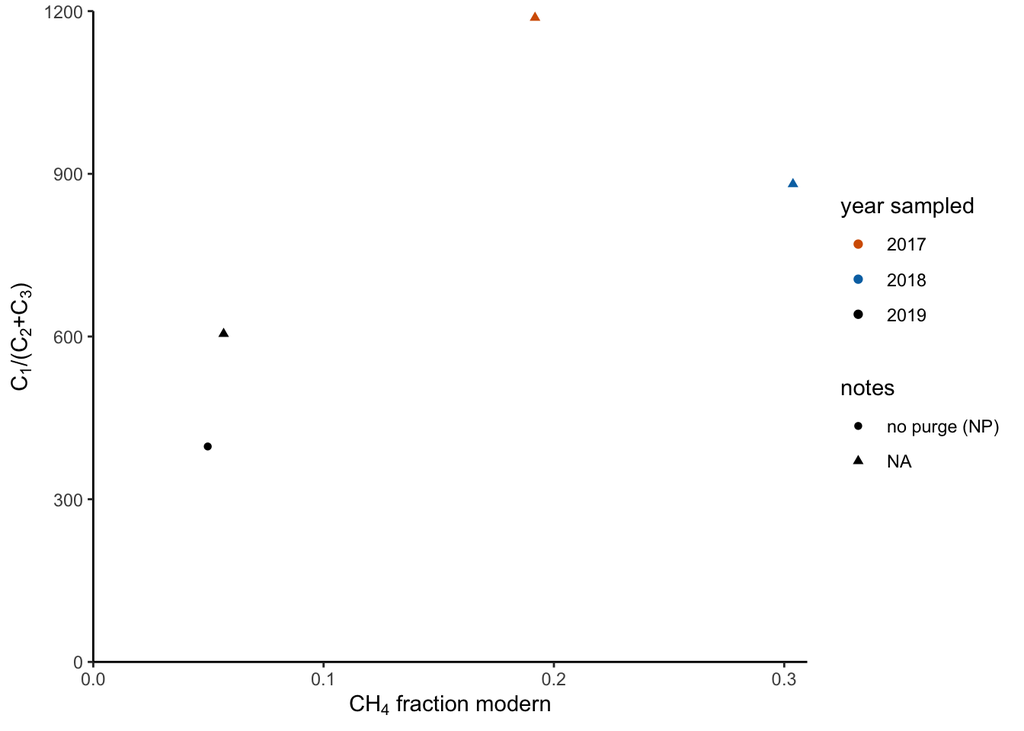

```r
data_C1_C2_C3_NSHQ14_2017_thru_2019_14C %>% ggplot(aes(x = CH4_Fm_UCIAMS, y = C1_over_C2_plus_C3, color = as.character(year_sampled), shape = notes))+
  geom_point()+
  scale_shape_discrete(na.value = 17) +
  scale_color_manual(name = "year sampled", values = cbPalette_MWL) +
  scale_x_continuous(name = TeX("CH$_4$ fraction modern"), limits = c(0,0.31), expand = c(0,0)) +
  scale_y_continuous(name = TeX("$C_1$/($C_{2}$+$C_{3}$)"), limits = c(0,1200), expand = c(0,0)) +
  theme_classic()
```

# 8 Rate comparisons

Methane concentration in 2017 in $\mu\text{mol}\,\text{L}^{-1}$

```r
conc_CH4_NSHQ14_2017_umol_per_L <- data %>% filter(sampling_site == "NSHQ14") %>%
  filter(year_sampled == 2017) %>%
  filter(depth_fluid_intake_mbct == 85) %>%
  select(CH4_uM) %>% as.numeric()

conc_CH4_NSHQ14_2017_umol_per_L
```

```
## [1] 105.5295
```

Methane fraction modern in 2017

```r
Fm_CH4_NSHQ14_2017 <- data %>% filter(sampling_site == "NSHQ14") %>%
  filter(year_sampled == 2017) %>%
  filter(depth_fluid_intake_mbct == 85) %>%
  select(CH4_Fm_UCIAMS) %>% as.numeric()

Fm_CH4_NSHQ14_2017
```

```
## [1] 0.1918
```

Concentration of modern methane in 2017

```r
conc_modern_CH4_NSHQ14_2017_umol_per_L <- conc_CH4_NSHQ14_2017_umol_per_L * Fm_CH4_NSHQ14_2017

conc_modern_CH4_NSHQ14_2017_umol_per_L
```

```
## [1] 20.24056
```

Rate comparison with Fones et al. 2019 “Physiological adaptations to serpentinization in the Samail Ophiolite, Oman” ISME J Calculate minimum time to form modern methane by microbial methanogenesis, in years

```r
NSHQ14_2017_max_methanogenesis_rate_pmol_per_mL_per_day <- 18 # Fones et al. 2019

NSHQ14_2017_max_methanogenesis_rate_pmol_per_L_per_day <- NSHQ14_2017_max_methanogenesis_rate_pmol_per_mL_per_day * 1000

NSHQ14_2017_max_methanogenesis_rate_umol_per_L_per_day <- NSHQ14_2017_max_methanogenesis_rate_pmol_per_L_per_day / 1e6

NSHQ14_2017_max_methanogenesis_rate_umol_per_L_per_year <- NSHQ14_2017_max_methanogenesis_rate_umol_per_L_per_day * 365

NSHQ14_2017_max_methanogenesis_rate_umol_per_L_per_year
```

```
## [1] 6.57
```

```r
min_time_to_form_modern_CH4_by_methanogenesis_NSHQ14_2017_year <- conc_modern_CH4_NSHQ14_2017_umol_per_L / NSHQ14_2017_max_methanogenesis_rate_umol_per_L_per_year

min_time_to_form_modern_CH4_by_methanogenesis_NSHQ14_2017_year
```

```
## [1] 3.080755
```

# 9 Sulfate and hydrogen comparisons

```r
data %>% filter(!is.na(CH4_Fm_UCIAMS)) %>% select(
sampling_site, year_sampled, month_sampled, day_sampled, depth_fluid_intake_mbct, CH4_Fm_UCIAMS, Sulfate_uM, Sulfate_was_measured, H2_uM, H2_was_measured, H2_LQ_uM)
```

| sampling_site | year_sampled | month_sampled | day_sampled | depth_fluid_intake_mbct | CH4_Fm_UCIAMS | Sulfate_uM | Sulfate_was_measured | H2_uM | H2_was_measured | H2_LQ_uM |
| --- | --- | --- | --- | --- | --- | --- | --- | --- | --- | --- |
| NSHQ14 | 2019 | 1 | 10 | 85 | 0.0566 | 47.325888 | TRUE | 245.2170 | TRUE | 3.289678 |
| NSHQ14 | 2019 | 1 | 18 | 85 | 0.0497 | 5.090259 | TRUE | 466.5118 | TRUE | 3.289678 |
| WAB71 | 2019 | 1 | 9 | 80 | 0.0050 | 50.965654 | TRUE | NA | TRUE | 3.289678 |
| CM2A | 2018 | 2 | 9 | 75 | 0.0002 | 556.168000 | TRUE | 3.3800 | TRUE | 0.598000 |
| NSHQ04 | 2018 | 2 | 3 | 8 | 0.0069 | NA | FALSE | NA | TRUE | 0.598000 |
| NSHQ14 | 2018 | 2 | 6 | 85 | 0.3038 | 156.580000 | TRUE | 131.0000 | TRUE | 0.598000 |
| WAB71 | 2018 | 2 | 3 | 70 | -0.0020 | 60.798000 | TRUE | NA | TRUE | 0.598000 |
| NSHQ14 | 2017 | 2 | 23 | 85 | 0.1918 | 2.000000 | TRUE | 253.2051 | TRUE | 0.048000 |

# 10 Henrys constant calculations

```r
R_m3_Pa_per_K_mol <- 8.31446261815324 # Gas constant

# Calculate Henry's constants at 22 ˚C and 37 ˚C
Henrys <- Henrys %>% mutate(Hcp_mol_per_m3_Pa_22C = Hcp_mol_per_m3_Pa_25C * exp(dlnHcp_over_d_inv_T * (1/(22+273.15) - 1/(25+273.15))))

Henrys <- Henrys %>% mutate(Hcp_mol_per_m3_Pa_37C = Hcp_mol_per_m3_Pa_25C * exp(dlnHcp_over_d_inv_T * (1/(37+273.15) - 1/(25+273.15))))

# Calculate Henry's constants at 22 ˚C and 37 ˚C

Henrys <- Henrys %>% mutate(Hcc_22C = Hcp_mol_per_m3_Pa_22C * R_m3_Pa_per_K_mol * (22+273.15))

Henrys <- Henrys %>% mutate(Hcc_37C = Hcp_mol_per_m3_Pa_37C * R_m3_Pa_per_K_mol * (37+273.15))

# Calculate % difference at 37 ˚C vs 22 ˚C
Henrys <- Henrys %>% mutate(Hcp_perc_diff_37C_22C = (Hcp_mol_per_m3_Pa_37C - Hcp_mol_per_m3_Pa_22C) / Hcp_mol_per_m3_Pa_22C * 100)

Henrys <- Henrys %>% mutate(Hcc_perc_diff_37C_22C = (Hcc_37C - Hcc_22C) / Hcc_22C * 100)

Henrys
```

| compound | Hcp_mol_per_m3_Pa_25C | dlnHcp_over_d_inv_T | Hcp_mol_per_m3_Pa_22C | Hcp_mol_per_m3_Pa_37C | Hcc_22C | Hcc_37C | Hcp_perc_diff_37C_22C | Hcc_perc_diff_37C_22C |
| --- | --- | --- | --- | --- | --- | --- | --- | --- |
| methane | 1.4e-05 | 1900 | 1.493684e-05 | 1.094075e-05 | 0.03665522 | 0.028213241 | -26.75328 | -23.03076 |
| ethane | 1.9e-05 | 2400 | 2.061993e-05 | 1.391532e-05 | 0.05060159 | 0.035883874 | -32.51517 | -29.08548 |
| propane | 1.5e-05 | 2700 | 1.644624e-05 | 1.056631e-05 | 0.04035929 | 0.027247675 | -35.75240 | -32.48723 |
| iso-butane | 9.1e-06 | 2700 | 9.977384e-06 | 6.410230e-06 | 0.02448464 | 0.016530256 | -35.75240 | -32.48723 |
| n-butane | 1.2e-05 | 3100 | 1.333763e-05 | 8.025463e-06 | 0.03273074 | 0.020695506 | -39.82844 | -36.77042 |
| iso-pentane | 7.2e-06 | 3400 | 8.084846e-06 | 4.631416e-06 | 0.01984032 | 0.011943174 | -42.71485 | -39.80353 |
| n-pentane | 8.0e-06 | 3400 | 8.983162e-06 | 5.146018e-06 | 0.02204480 | 0.013270194 | -42.71485 | -39.80353 |
| hexane | 6.1e-06 | 3800 | 6.943707e-06 | 3.725356e-06 | 0.01703995 | 0.009606689 | -46.34918 | -43.62255 |

Get relevant gas data

```r
data_14CH4_2019_gas_concs <- data %>% filter(year_sampled == 2019) %>% filter(sampling_site == "NSHQ14" | sampling_site == "WAB71") %>% select(sampling_site, notes, CH4_uM, CH4_LQ_uM, C2H6_uM, C2H6_LQ_uM, C3H8_uM, C3H8_LQ_uM, i_C4H10_uM, i_C4H10_LQ_uM, n_C4H10_uM, n_C4H10_LQ_uM, i_C5H12_uM, i_C5H12_LQ_uM, n_C5H12_uM, n_C5H12_LQ_uM, C6H14_uM, C6H12_LQ_uM)

data_14CH4_2019_gas_concs
```

| sampling_site | notes | CH4_uM | CH4_LQ_uM | C2H6_uM | C2H6_LQ_uM | C3H8_uM | C3H8_LQ_uM | i_C4H10_uM | i_C4H10_LQ_uM | n_C4H10_uM | n_C4H10_LQ_uM | i_C5H12_uM | i_C5H12_LQ_uM | n_C5H12_uM | n_C5H12_LQ_uM | C6H14_uM | C6H12_LQ_uM |
| --- | --- | --- | --- | --- | --- | --- | --- | --- | --- | --- | --- | --- | --- | --- | --- | --- | --- |
| NSHQ14 | NA | 73.11120 | 0.6695845 | 0.1081013 | 0.008630547 | 0.01274837 | 0.00681359 | NA | 0.004133578 | NA | 0.005450872 | NA | 0.003270523 | 0.004043899 | 0.003633915 | 0.007165596 | 0.00277086 |
| NSHQ14 | no purge (NP) | 128.04151 | 0.6695845 | 0.2911754 | 0.008630547 | 0.03113155 | 0.00681359 | NA | 0.004133578 | NA | 0.005450872 | NA | 0.003270523 | NA | 0.003633915 | 0.008341432 | 0.00277086 |
| WAB71 | Water was intermittently clear and highly sediment-rich. Particulate filters loaded with much sediment. | 25.37656 | 0.6695845 | NA | 0.008630547 | NA | 0.00681359 | NA | 0.004133578 | NA | 0.005450872 | NA | 0.003270523 | NA | 0.003633915 | 0.007127690 | 0.00277086 |

calculate equilibrium gas phase concentration

```r
data_14CH4_2019_gas_concs_gas_phase <- data_14CH4_2019_gas_concs %>%
  mutate(CH4_uM = CH4_uM / Henrys %>% filter(compound == "methane") %>% select(Hcc_22C) %>% as.numeric(),
          CH4_LQ_uM = CH4_LQ_uM / Henrys %>% filter(compound == "methane") %>% select(Hcc_22C) %>% as.numeric(),
          C2H6_uM = C2H6_uM / Henrys %>% filter(compound == "ethane") %>% select(Hcc_22C) %>% as.numeric(),
          C2H6_LQ_uM = C2H6_LQ_uM / Henrys %>% filter(compound == "ethane") %>% select(Hcc_22C) %>% as.numeric(),
          C3H8_uM = C3H8_uM / Henrys %>% filter(compound == "propane") %>% select(Hcc_22C) %>% as.numeric(),
          C3H8_LQ_uM = C3H8_LQ_uM / Henrys %>% filter(compound == "propane") %>% select(Hcc_22C) %>% as.numeric(),
          i_C4H10_uM = i_C4H10_uM / Henrys %>% filter(compound == "iso-butane") %>% select(Hcc_22C) %>% as.numeric(),
          i_C4H10_LQ_uM = i_C4H10_LQ_uM / Henrys %>% filter(compound == "iso-butane") %>% select(Hcc_22C) %>% as.numeric(),
          n_C4H10_uM = n_C4H10_uM / Henrys %>% filter(compound == "n-butane") %>% select(Hcc_22C) %>% as.numeric(),
          n_C4H10_LQ_uM = n_C4H10_LQ_uM / Henrys %>% filter(compound == "n-butane") %>% select(Hcc_22C) %>% as.numeric(),
          i_C5H12_uM = i_C5H12_uM / Henrys %>% filter(compound == "iso-pentane") %>% select(Hcc_22C) %>% as.numeric(),
          i_C5H12_LQ_uM = i_C5H12_LQ_uM / Henrys %>% filter(compound == "iso-pentane") %>% select(Hcc_22C) %>% as.numeric(),
          n_C5H12_uM = n_C5H12_uM / Henrys %>% filter(compound == "n-pentane") %>% select(Hcc_22C) %>% as.numeric(),
          n_C5H12_LQ_uM = n_C5H12_LQ_uM / Henrys %>% filter(compound == "n-pentane") %>% select(Hcc_22C) %>% as.numeric(),
          C6H14_uM = C6H14_uM / Henrys %>% filter(compound == "hexane") %>% select(Hcc_22C) %>% as.numeric(),
          C6H12_LQ_uM = C6H12_LQ_uM / Henrys %>% filter(compound == "hexane") %>% select(Hcc_22C) %>% as.numeric()
                                                                              )

data_14CH4_2019_gas_concs_gas_phase
```

| sampling_site | notes | CH4_uM | CH4_LQ_uM | C2H6_uM | C2H6_LQ_uM | C3H8_uM | C3H8_LQ_uM | i_C4H10_uM | i_C4H10_LQ_uM | n_C4H10_uM | n_C4H10_LQ_uM | i_C5H12_uM | i_C5H12_LQ_uM | n_C5H12_uM | n_C5H12_LQ_uM | C6H14_uM | C6H12_LQ_uM |
| --- | --- | --- | --- | --- | --- | --- | --- | --- | --- | --- | --- | --- | --- | --- | --- | --- | --- |
| NSHQ14 | NA | 1994.5649 | 18.2671 | 2.136321 | 0.1705588 | 0.3158719 | 0.1688233 | NA | 0.1688233 | NA | 0.1665368 | NA | 0.1648422 | 0.18344 | 0.1648422 | 0.4205174 | 0.1626096 |
| NSHQ14 | no purge (NP) | 3493.1322 | 18.2671 | 5.754274 | 0.1705588 | 0.7713603 | 0.1688233 | NA | 0.1688233 | NA | 0.1665368 | NA | 0.1648422 | NA | 0.1648422 | 0.4895221 | 0.1626096 |
| WAB71 | Water was intermittently clear and highly sediment-rich. Particulate filters loaded with much sediment. | 692.3041 | 18.2671 | NA | 0.1705588 | NA | 0.1688233 | NA | 0.1688233 | NA | 0.1665368 | NA | 0.1648422 | NA | 0.1648422 | 0.4182929 | 0.1626096 |

```r
# calculate C1/(C2+C3)
data_14CH4_2019_gas_concs_gas_phase <- data_14CH4_2019_gas_concs_gas_phase %>% mutate(C1_over_C2_plus_C3 = CH4_uM / (C2H6_uM + if_else(!is.na(C3H8_uM), C3H8_uM, 0)))

data_14CH4_2019_gas_concs_gas_phase %>% select(sampling_site, C1_over_C2_plus_C3, notes)
```

| sampling_site | C1_over_C2_plus_C3 | notes |
| --- | --- | --- |
| NSHQ14 | 813.3799 | NA |
| NSHQ14 | 535.2939 | no purge (NP) |
| WAB71 | NA | Water was intermittently clear and highly sediment-rich. Particulate filters loaded with much sediment. |

```r
# calculate C1/(C moles in total C1-C6)
data_14CH4_2019_gas_concs_gas_phase <- data_14CH4_2019_gas_concs_gas_phase %>% mutate(mol_C_in_C1_over_mol_C_C1_thru_C6 = CH4_uM / (CH4_uM + if_else(is.na(C2H6_uM) == FALSE, C2H6_uM, 0) * 2 + if_else(is.na(C3H8_uM) == FALSE, C3H8_uM, 0) * 3 + if_else(is.na(i_C4H10_uM) == FALSE, i_C4H10_uM, 0) * 4 + if_else(is.na(n_C4H10_uM) == FALSE, n_C4H10_uM, 0) * 4 + if_else(is.na(i_C5H12_uM) == FALSE, i_C4H10_uM, 0) * 5 + if_else(is.na(n_C5H12_uM) == FALSE, n_C5H12_uM, 0) * 5 + if_else(is.na(C6H14_uM) == FALSE, C6H14_uM, 0) * 6))

data_14CH4_2019_gas_concs_gas_phase %>% select(sampling_site, mol_C_in_C1_over_mol_C_C1_thru_C6, notes)
```

| sampling_site | mol_C_in_C1_over_mol_C_C1_thru_C6 | notes |
| --- | --- | --- |
| NSHQ14 | 0.9956767 | NA |
| NSHQ14 | 0.9952250 | no purge (NP) |
| WAB71 | 0.9963879 | Water was intermittently clear and highly sediment-rich. Particulate filters loaded with much sediment. |

Calculate what the F$^{14}$C of the total gaseous hydrocarbon pool would be if CH$_4$ had F$^{14}$C = 0 and non-methane hydrocarbon gases (NMHC) had F$^{14}$C = 1 assuming gas concentrations ratios from samples in prior chunk

```r
F14C_NMHC_hypo <- 1 # hypothetical assumption of fraction modern of total non-methane hydrocarbon pool
F14C_CH4_hypo <- 0 # hypothetical assumption of fraction modern of total non-methane hydrocarbon pool

data_14CH4_2019_gas_concs_gas_phase_hypo_dead_CH4 <- data_14CH4_2019_gas_concs_gas_phase %>%
  mutate(F14C_tot_HC_hypo = mol_C_in_C1_over_mol_C_C1_thru_C6 * F14C_CH4_hypo + (1 - mol_C_in_C1_over_mol_C_C1_thru_C6) * F14C_NMHC_hypo)

data_14CH4_2019_gas_concs_gas_phase_hypo_dead_CH4 %>% select(sampling_site, F14C_tot_HC_hypo, mol_C_in_C1_over_mol_C_C1_thru_C6, notes)
```

| sampling_site | F14C_tot_HC_hypo | mol_C_in_C1_over_mol_C_C1_thru_C6 | notes |
| --- | --- | --- | --- |
| NSHQ14 | 0.004323309 | 0.9956767 | NA |
| NSHQ14 | 0.004775008 | 0.9952250 | no purge (NP) |
| WAB71 | 0.003612129 | 0.9963879 | Water was intermittently clear and highly sediment-rich. Particulate filters loaded with much sediment. |

Calculate what the F$^{14}$C of the total gaseous hydrocarbon pool would be if CH$_4$ had F$^{14}$C = 1 and non-methane hydrocarbon gases (NMHC) had F$^{14}$C = 0 assuming gas concentrations ratios from samples in prior chunk

```r
F14C_NMHC_hypo <- 0 # hypothetical assumption of fraction modern of total non-methane hydrocarbon pool
F14C_CH4_hypo <- 1 # hypothetical assumption of fraction modern of total non-methane hydrocarbon pool

data_14CH4_2019_gas_concs_gas_phase_hypo_dead_NMHC <- data_14CH4_2019_gas_concs_gas_phase %>%
  mutate(F14C_tot_HC_hypo = mol_C_in_C1_over_mol_C_C1_thru_C6 * F14C_CH4_hypo + (1 - mol_C_in_C1_over_mol_C_C1_thru_C6) * F14C_NMHC_hypo)

data_14CH4_2019_gas_concs_gas_phase_hypo_dead_NMHC %>% select(sampling_site, F14C_tot_HC_hypo, mol_C_in_C1_over_mol_C_C1_thru_C6, notes)
```

| sampling_site | F14C_tot_HC_hypo | mol_C_in_C1_over_mol_C_C1_thru_C6 | notes |
| --- | --- | --- | --- |
| NSHQ14 | 0.9956767 | 0.9956767 | NA |
| NSHQ14 | 0.9952250 | 0.9952250 | no purge (NP) |
| WAB71 | 0.9963879 | 0.9963879 | Water was intermittently clear and highly sediment-rich. Particulate filters loaded with much sediment. |

Calculate what the F$^{14}$C of the total gaseous hydrocarbon pool would be if CH$_4$ had F$^{14}$C of measured value of NSHQ14 2019 prepared at Isotech and measured at NOSAMS and non-methane hydrocarbon gases (NMHC) had F$^{14}$C = 0 assuming gas concentrations ratios from samples in prior chunk

```r
F14C_NMHC_hypo <- 0 # hypothetical assumption of fraction modern of total non-methane hydrocarbon pool
(F14C_CH4_measured_NOSAMS <- data %>% filter(sampling_site == "NSHQ14" & year_sampled == 2019 & is.na(notes) == T) %>% select(CH4_Fm_NOSAMS) %>% as.character() %>% as.numeric()) # hypothetical assumption of fraction modern of total non-methane hydrocarbon pool
```

```
## [1] 0.0614
```

```r
data_14CH4_2019_gas_concs_gas_phase_hypo_dead_NMHC_measured_NSHQ14_f14C_CH4 <- data_14CH4_2019_gas_concs_gas_phase %>% filter(sampling_site == "NSHQ14" & is.na(notes) == T) %>%
  mutate(F14C_tot_HC_hypo = mol_C_in_C1_over_mol_C_C1_thru_C6 * F14C_CH4_measured_NOSAMS + (1 - mol_C_in_C1_over_mol_C_C1_thru_C6) * F14C_NMHC_hypo)

data_14CH4_2019_gas_concs_gas_phase_hypo_dead_NMHC_measured_NSHQ14_f14C_CH4 %>% select(sampling_site, F14C_tot_HC_hypo, mol_C_in_C1_over_mol_C_C1_thru_C6, notes)
```

| sampling_site | F14C_tot_HC_hypo | mol_C_in_C1_over_mol_C_C1_thru_C6 | notes |
| --- | --- | --- | --- |
| NSHQ14 | 0.06113455 | 0.9956767 | NA |

```r
F14C_CH4_hypo <- data_14CH4_2019_gas_concs_gas_phase_hypo_dead_NMHC_measured_NSHQ14_f14C_CH4 %>% select(F14C_tot_HC_hypo) %>% as.character %>% as.numeric()

# calculate difference between measured and hypothetical F14C CH4 at NSHQ14 in 2019
(F14C_CH4_diff_measured_hypo <- F14C_CH4_measured_NOSAMS - F14C_CH4_hypo)
```

```
## [1] 0.0002654512
```

F$^{14}$C of total hydrocarbon gases in NSHQ14 in 2019 measured at UC-Irvine and prepared at CU-Boulder

```r
(F14C_CH4_measured_UCI <- data %>% filter(sampling_site == "NSHQ14" & year_sampled == 2019 & is.na(notes) == T) %>% select(CH4_Fm_UCIAMS) %>% as.character() %>% as.numeric())
```

```
## [1] 0.0566
```

```r
# calculate difference between measured F14C CH4 at NSHQ14 in 2019 at NOSAMS and UCI
(F14C_CH4_diff_NOSAMS_UCI <- F14C_CH4_measured_NOSAMS - F14C_CH4_measured_UCI)
```

```
## [1] 0.0048
```

% of difference between NOSAMS and UCI F$^{14}$C attributable to dilution of NMHCs

```r
F14C_CH4_diff_measured_hypo / F14C_CH4_diff_NOSAMS_UCI * 100
```

```
## [1] 5.530233
```

Calculate relative difference (%) of the UCI and NOSAMS samples

```r
(F14C_CH4_measured_NOSAMS - F14C_CH4_measured_UCI) / mean(F14C_CH4_measured_NOSAMS, F14C_CH4_measured_UCI) * 100
```

```
## [1] 7.81759
```

# 11 Anderson-Schulz-Flory distribution

## 11.1 NSQH14

Get the relevant data

```r
# select relevant hydrocarbon concentration data from well NSHQ14
data_ASF_NSHQ14 <- data %>% filter(sampling_site == "NSHQ14") %>% select(year_sampled, depth_fluid_intake_mbct, notes, CH4_uM, C2H6_uM, C3H8_uM, n_C4H10_uM, i_C4H10_uM, n_C5H12_uM, i_C5H12_uM, C6H14_uM)

# sum concentrations of compounds of same carbon number
data_ASF_NSHQ14_sumC4_C5 <- data_ASF_NSHQ14 %>%
  rowwise() %>%  # Treat each row as a group for calculations
  mutate(
    C4_sum = sum(n_C4H10_uM,i_C4H10_uM, na.rm = T), # Select columns and replace NAs with 0
    C5_sum = sum(n_C5H12_uM,i_C5H12_uM, na.rm = T) # Select columns and replace NAs with 0
  ) %>%
  ungroup() %>%  # Remove rowwise grouping
select(year_sampled, year_sampled, depth_fluid_intake_mbct, notes, CH4_uM, C2H6_uM, C3H8_uM, C4_sum, C5_sum, C6H14_uM) %>%
  filter(!is.na(C3H8_uM)) #filter out samples that don't at least have a propane detection

data_ASF_NSHQ14
```

| year_sampled | depth_fluid_intake_mbct | notes | CH4_uM | C2H6_uM | C3H8_uM | n_C4H10_uM | i_C4H10_uM | n_C5H12_uM | i_C5H12_uM | C6H14_uM |
| --- | --- | --- | --- | --- | --- | --- | --- | --- | --- | --- |
| 2019 | 85 | NA | 73.11120 | 0.10810127 | 0.012748365 | NA | NA | 0.004043899 | NA | 0.0071655955 |
| 2019 | 85 | no purge (NP) | 128.04151 | 0.29117543 | 0.031131554 | NA | NA | NA | NA | 0.0083414319 |
| 2018 | 85 | NA | 71.23263 | 0.07320627 | 0.007638227 | 0.002877249 | 0.002259763 | 0.002225777 | 0.001267175 | 0.0011154228 |
| 2017 | 18 | NA | NA | NA | NA | NA | NA | NA | NA | NA |
| 2017 | 50 | NA | 53.51237 | 0.03648183 | 0.004978709 | 0.005868302 | NA | 0.001551230 | NA | 0.0007457877 |
| 2017 | 85 | NA | 105.52952 | 0.07983581 | 0.009004187 | 0.004767922 | 0.001525745 | 0.002276812 | NA | 0.0009660762 |
| 2016 | 70 | NA | 49.00000 | NA | NA | NA | NA | NA | NA | NA |
| 2015 | 20 | NA | 120.00000 | NA | NA | NA | NA | NA | NA | NA |
| 2014 | 18 | NA | 170.00000 | NA | NA | NA | NA | NA | NA | NA |
| 2014 | 262 | NA | 40.00000 | NA | NA | NA | NA | NA | NA | NA |

[output cut: 3 more lines]

```r
data_ASF_NSHQ14_sumC4_C5
```

| year_sampled | depth_fluid_intake_mbct | notes | CH4_uM | C2H6_uM | C3H8_uM | C4_sum | C5_sum | C6H14_uM |
| --- | --- | --- | --- | --- | --- | --- | --- | --- |
| 2019 | 85 | NA | 73.11120 | 0.10810127 | 0.012748365 | 0.000000000 | 0.004043899 | 0.0071655955 |
| 2019 | 85 | no purge (NP) | 128.04151 | 0.29117543 | 0.031131554 | 0.000000000 | 0.000000000 | 0.0083414319 |
| 2018 | 85 | NA | 71.23263 | 0.07320627 | 0.007638227 | 0.005137012 | 0.003492952 | 0.0011154228 |
| 2017 | 50 | NA | 53.51237 | 0.03648183 | 0.004978709 | 0.005868302 | 0.001551230 | 0.0007457877 |
| 2017 | 85 | NA | 105.52952 | 0.07983581 | 0.009004187 | 0.006293668 | 0.002276812 | 0.0009660762 |

Calculate mole fractions

```r
data_ASF_NSHQ14_sumC4_C5 <- data_ASF_NSHQ14_sumC4_C5 %>%
    rowwise() %>%  # Treat each row as a group for calculations
  mutate(
    sum_C1_thru_C6 = sum(
            c_across(CH4_uM:C6H14_uM))
    ) %>%
  ungroup() # Remove rowwise grouping

# calculate mole fractions
data_ASF_NSHQ14_mol_frac <- data_ASF_NSHQ14_sumC4_C5 %>%
  mutate(
C1_mol_frac = CH4_uM / sum_C1_thru_C6,
C2_mol_frac = C2H6_uM / sum_C1_thru_C6,
C3_mol_frac = C3H8_uM / sum_C1_thru_C6,
C4_mol_frac = C4_sum / sum_C1_thru_C6,
C5_mol_frac = C5_sum / sum_C1_thru_C6,
C6_mol_frac = C6H14_uM / sum_C1_thru_C6,
    ) %>%
  select(year_sampled, year_sampled, depth_fluid_intake_mbct, notes, C1_mol_frac, C2_mol_frac, C3_mol_frac, C4_mol_frac, C5_mol_frac, C6_mol_frac)


data_ASF_NSHQ14_sumC4_C5
```

| year_sampled | depth_fluid_intake_mbct | notes | CH4_uM | C2H6_uM | C3H8_uM | C4_sum | C5_sum | C6H14_uM | sum_C1_thru_C6 |
| --- | --- | --- | --- | --- | --- | --- | --- | --- | --- |
| 2019 | 85 | NA | 73.11120 | 0.10810127 | 0.012748365 | 0.000000000 | 0.004043899 | 0.0071655955 | 73.24326 |
| 2019 | 85 | no purge (NP) | 128.04151 | 0.29117543 | 0.031131554 | 0.000000000 | 0.000000000 | 0.0083414319 | 128.37216 |
| 2018 | 85 | NA | 71.23263 | 0.07320627 | 0.007638227 | 0.005137012 | 0.003492952 | 0.0011154228 | 71.32322 |
| 2017 | 50 | NA | 53.51237 | 0.03648183 | 0.004978709 | 0.005868302 | 0.001551230 | 0.0007457877 | 53.56200 |
| 2017 | 85 | NA | 105.52952 | 0.07983581 | 0.009004187 | 0.006293668 | 0.002276812 | 0.0009660762 | 105.62790 |

```r
data_ASF_NSHQ14_mol_frac
```

| year_sampled | depth_fluid_intake_mbct | notes | C1_mol_frac | C2_mol_frac | C3_mol_frac | C4_mol_frac | C5_mol_frac | C6_mol_frac |
| --- | --- | --- | --- | --- | --- | --- | --- | --- |
| 2019 | 85 | NA | 0.9981970 | 0.0014759209 | 1.740551e-04 | 0.000000e+00 | 5.521189e-05 | 9.783283e-05 |
| 2019 | 85 | no purge (NP) | 0.9974243 | 0.0022682132 | 2.425102e-04 | 0.000000e+00 | 0.000000e+00 | 6.497851e-05 |
| 2018 | 85 | NA | 0.9987299 | 0.0010264017 | 1.070931e-04 | 7.202440e-05 | 4.897357e-05 | 1.563899e-05 |
| 2017 | 50 | NA | 0.9990735 | 0.0006811140 | 9.295226e-05 | 1.095609e-04 | 2.896139e-05 | 1.392382e-05 |
| 2017 | 85 | NA | 0.9990686 | 0.0007558212 | 8.524440e-05 | 5.958339e-05 | 2.155503e-05 | 9.146033e-06 |

Prep for plotting

```r
# make carbon number its own column for plotting
data_ASF_NSHQ14_mol_frac_longer <- data_ASF_NSHQ14_mol_frac %>% pivot_longer(
  cols = starts_with("C"),
  names_to = "C_number",
  values_to = "mol_frac"
) %>% mutate(
  C_number = C_number %>% str_sub(2,2) %>% as.numeric()
)

# take log10 of mol_frac
data_ASF_NSHQ14_mol_frac_longer <- data_ASF_NSHQ14_mol_frac_longer %>%
  filter(mol_frac != 0) %>% # remove rows of 0 mol fraction
  mutate(log10_mol_frac = log10(mol_frac)) # take log10


data_ASF_NSHQ14_mol_frac_longer
```

| year_sampled | depth_fluid_intake_mbct | notes | C_number | mol_frac | log10_mol_frac |
| --- | --- | --- | --- | --- | --- |
| 2019 | 85 | NA | 1 | 9.981970e-01 | -0.0007837487 |
| 2019 | 85 | NA | 2 | 1.475921e-03 | -2.8309369046 |
| 2019 | 85 | NA | 3 | 1.740551e-04 | -3.7593131975 |
| 2019 | 85 | NA | 5 | 5.521189e-05 | -4.2579674175 |
| 2019 | 85 | NA | 6 | 9.783283e-05 | -4.0095153976 |
| 2019 | 85 | no purge (NP) | 1 | 9.974243e-01 | -0.0011200562 |
| 2019 | 85 | no purge (NP) | 2 | 2.268213e-03 | -2.6443161210 |
| 2019 | 85 | no purge (NP) | 3 | 2.425102e-04 | -3.6152700488 |
| 2019 | 85 | no purge (NP) | 6 | 6.497851e-05 | -4.1872302418 |
| 2018 | 85 | NA | 1 | 9.987299e-01 | -0.0005519618 |

[output cut: 17 more lines]

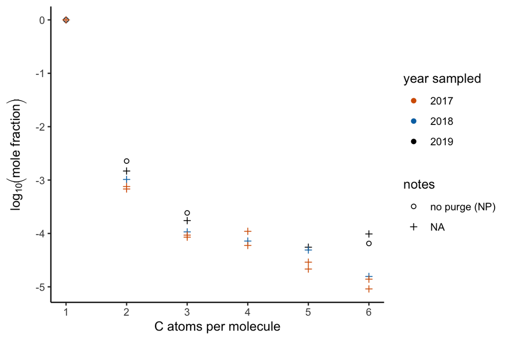

```r
data_ASF_NSHQ14_mol_frac_longer %>% ggplot(aes(x = C_number, y = log10_mol_frac, color = as.character(year_sampled), shape = notes, ))+
  geom_point()+
  scale_shape_manual(values = c(1), na.value = 3) +
  scale_color_manual(name = "year sampled", values = cbPalette_MWL) +
  scale_x_continuous(name = "C atoms per molecule", n.breaks = 6) +
  scale_y_continuous(name = TeX("log$_{10}\\left($mole fraction$\\right)$")) +
  theme_classic()
```

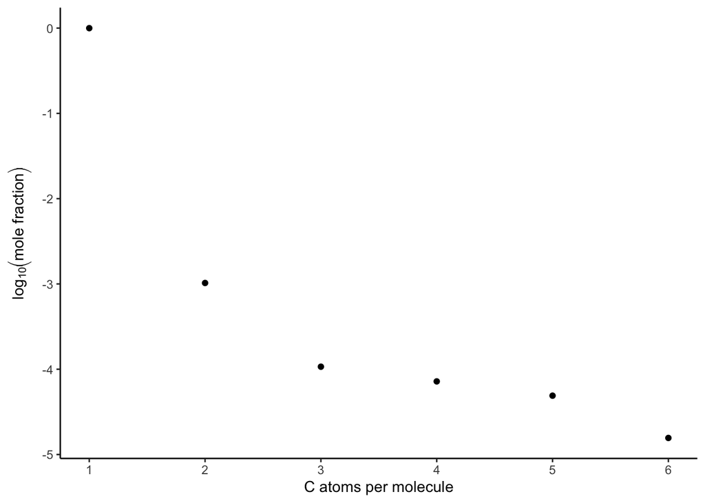

```r
data_ASF_NSHQ14_mol_frac_longer_2018 <- data_ASF_NSHQ14_mol_frac_longer %>% filter(year_sampled == 2018)

data_ASF_NSHQ14_mol_frac_longer_2018_plot <- data_ASF_NSHQ14_mol_frac_longer_2018 %>% ggplot(aes(x = C_number, y = log10_mol_frac))+
  geom_point()+
  scale_shape_discrete(na.value = 17) +
  scale_color_manual(values = cbPalette_MWL) +
  scale_x_continuous(name = "C atoms per molecule", n.breaks = 6) +
  scale_y_continuous(name = TeX("log$_{10}\\left($mole fraction$\\right)$")) +
  theme_classic()

data_ASF_NSHQ14_mol_frac_longer_2018_plot
```

```r
data_ASF_NSHQ14_mol_frac_longer_2018_C2_C6 <- data_ASF_NSHQ14_mol_frac_longer_2018 %>% filter(C_number > 1)

# generate linear model
model_NSHQ14_mol_frac_longer_2018_C2_C6 = lm(log10_mol_frac ~ C_number,
           data = data_ASF_NSHQ14_mol_frac_longer_2018_C2_C6)

model_NSHQ14_mol_frac_longer_2018_C2_C6_int <- coef(model_NSHQ14_mol_frac_longer_2018_C2_C6)[1] %>% as.numeric()
model_NSHQ14_mol_frac_longer_2018_C2_C6_slope <- coef(model_NSHQ14_mol_frac_longer_2018_C2_C6)[2] %>% as.numeric()

# print model summary
summary(model_NSHQ14_mol_frac_longer_2018_C2_C6)
```

```
##
## Call:
## lm(formula = log10_mol_frac ~ C_number, data = data_ASF_NSHQ14_mol_frac_longer_2018_C2_C6)
##
## Residuals:
##        1        2        3        4        5
##  0.25997 -0.32419 -0.09907  0.13082  0.03247
##
## Coefficients:
##             Estimate Std. Error t value Pr(>|t|)
## (Intercept) -2.45385    0.34698  -7.072  0.00581 **
## C_number    -0.39740    0.08178  -4.859  0.01664 *
## ---
## Signif. codes:  0 '***' 0.001 '**' 0.01 '*' 0.05 '.' 0.1 ' ' 1
##
## Residual standard error: 0.2586 on 3 degrees of freedom
## Multiple R-squared:  0.8873, Adjusted R-squared:  0.8497
## F-statistic: 23.61 on 1 and 3 DF,  p-value: 0.01664
```

```r
model_NSHQ14_mol_frac_longer_2018_C2_C6_int
```

```
## [1] -2.453847
```

```r
model_NSHQ14_mol_frac_longer_2018_C2_C6_slope
```

```
## [1] -0.3974017
```

Calculate chain-growth probability factor from slope and intercept for C2-C6 region

```r
(alpha_ASF_slope_NSHQ14_2018_C2_C6 <- 10^model_NSHQ14_mol_frac_longer_2018_C2_C6_slope)
```

```
## [1] 0.4004961
```

```r
(alpha_ASF_int_NSHQ14_2018_C2_C6 <- 1 - 10^model_NSHQ14_mol_frac_longer_2018_C2_C6_int)
```

```
## [1] 0.9964832
```

```r
data_ASF_NSHQ14_mol_frac_longer_2018_C2_C4 <- data_ASF_NSHQ14_mol_frac_longer_2018 %>% filter(C_number > 1 & C_number < 5)

# generate linear model
model_NSHQ14_mol_frac_longer_2018_C2_C4 = lm(log10_mol_frac ~ C_number,
           data = data_ASF_NSHQ14_mol_frac_longer_2018_C2_C4)

model_NSHQ14_mol_frac_longer_2018_C2_C4_int <- coef(model_NSHQ14_mol_frac_longer_2018_C2_C4)[1] %>% as.numeric()
model_NSHQ14_mol_frac_longer_2018_C2_C4_slope <- coef(model_NSHQ14_mol_frac_longer_2018_C2_C4)[2] %>% as.numeric()

# print model summary
summary(model_NSHQ14_mol_frac_longer_2018_C2_C4)
```

```
##
## Call:
## lm(formula = log10_mol_frac ~ C_number, data = data_ASF_NSHQ14_mol_frac_longer_2018_C2_C4)
##
## Residuals:
##       1       2       3
##  0.1349 -0.2698  0.1349
##
## Coefficients:
##             Estimate Std. Error t value Pr(>|t|)
## (Intercept)  -1.9697     0.7263  -2.712    0.225
## C_number     -0.5769     0.2336  -2.470    0.245
##
## Residual standard error: 0.3304 on 1 degrees of freedom
## Multiple R-squared:  0.8591, Adjusted R-squared:  0.7182
## F-statistic: 6.098 on 1 and 1 DF,  p-value: 0.2449
```

```r
model_NSHQ14_mol_frac_longer_2018_C2_C4_int
```

```
## [1] -1.969724
```

```r
model_NSHQ14_mol_frac_longer_2018_C2_C4_slope
```

```
## [1] -0.5769189
```

Calculate chain-growth probability factor from slope and intercept for C2-C4 region

```r
(alpha_ASF_slope_NSHQ14_2018_C2_C4 <- 10^model_NSHQ14_mol_frac_longer_2018_C2_C4_slope)
```

```
## [1] 0.2648995
```

```r
(alpha_ASF_int_NSHQ14_2018_C2_C4 <- 1 - 10^model_NSHQ14_mol_frac_longer_2018_C2_C4_int)
```

```
## [1] 0.989278
```

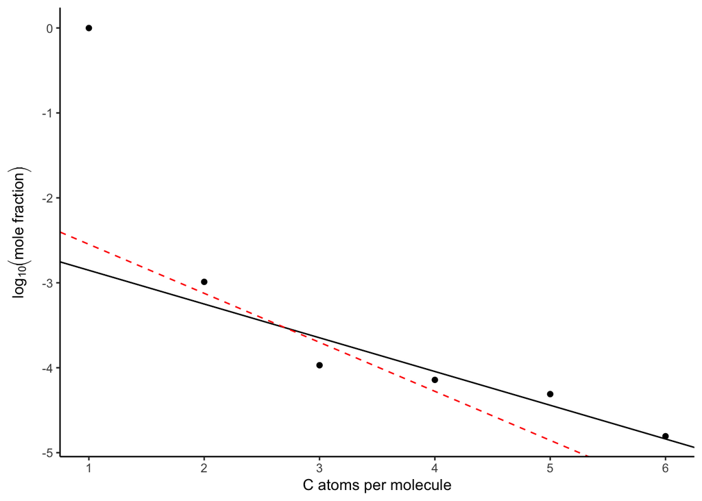

```r
data_ASF_NSHQ14_mol_frac_longer_2018_plot +
  geom_abline(aes(intercept = model_NSHQ14_mol_frac_longer_2018_C2_C6_int, slope = model_NSHQ14_mol_frac_longer_2018_C2_C6_slope)) +
    geom_abline(aes(intercept = model_NSHQ14_mol_frac_longer_2018_C2_C4_int, slope = model_NSHQ14_mol_frac_longer_2018_C2_C4_slope), linetype="dashed", color = "red")
```

## 11.2 Lost City

Get the relevant data

```r
# select relevant hydrocarbon concentration data from Lost City (Proskurowski et al., 2008)
data_ASF_LCHF <- data_literature %>% filter(site == "Lost City") %>% filter(author == "Proskurowski et al.") %>% select(CH4_conc, C2H6_conc, C2H4_conc, C3H8_conc, n_C4H10_conc, i_C4H10_conc)

data_ASF_LCHF
```

| CH4_conc | C2H6_conc | C2H4_conc | C3H8_conc | n_C4H10_conc | i_C4H10_conc |
| --- | --- | --- | --- | --- | --- |
| 1320 | 1.04 | 0.013 | 0.098 | 0.029 | 0.001 |
| 1380 | 1.23 | 0.018 | 0.100 | 0.017 | 0.002 |
| 1340 | 1.24 | 0.007 | 0.110 | 0.005 | 0.012 |
| 1060 | 0.91 | 0.007 | 0.087 | 0.012 | 0.007 |
| 1440 | 1.22 | 0.001 | 0.100 | 0.010 | 0.009 |
| 1700 | 1.37 | 0.014 | 0.130 | NA | 0.001 |
| 1390 | 1.23 | NA | 0.107 | 0.008 | NA |
| 1140 | 1.17 | 0.013 | 0.091 | 0.012 | 0.014 |
| 1210 | 1.15 | 0.005 | 0.100 | 0.014 | 0.009 |
| 1280 | 1.16 | 0.007 | 0.099 | 0.018 | 0.005 |

[output cut: 20 more lines]

```r
# sum concentrations of compounds of same carbon number
data_ASF_LCHF_sumC2_C4 <- data_ASF_LCHF %>%
  rowwise() %>%  # Treat each row as a group for calculations
  mutate(
    C2_sum = sum(C2H6_conc, C2H4_conc, na.rm = T), # Select columns and replace NAs with 0
    C4_sum = sum(n_C4H10_conc,i_C4H10_conc, na.rm = T) # Select columns and replace NAs with 0
  ) %>%
  ungroup() %>%  # Remove rowwise grouping
select(CH4_conc, C2_sum, C3H8_conc, C4_sum)

data_ASF_LCHF_sumC2_C4
```

| CH4_conc | C2_sum | C3H8_conc | C4_sum |
| --- | --- | --- | --- |
| 1320 | 1.053 | 0.098 | 0.030 |
| 1380 | 1.248 | 0.100 | 0.019 |
| 1340 | 1.247 | 0.110 | 0.017 |
| 1060 | 0.917 | 0.087 | 0.019 |
| 1440 | 1.221 | 0.100 | 0.019 |
| 1700 | 1.384 | 0.130 | 0.001 |
| 1390 | 1.230 | 0.107 | 0.008 |
| 1140 | 1.183 | 0.091 | 0.026 |
| 1210 | 1.155 | 0.100 | 0.023 |
| 1280 | 1.167 | 0.099 | 0.023 |

[output cut: 20 more lines]

Summarize Lost City data absolute concentrations

```r
# calculate means and standard errors
data_ASF_LCHF_conc_summ <- data_ASF_LCHF_sumC2_C4 %>% summarise(
  n=n(),
  C1_conc_mean = mean(CH4_conc),
  C1_mol_frac_stderr = sd(CH4_conc) / sqrt(length(CH4_conc)),
  C1_stderr_over_mean_percent = C1_mol_frac_stderr / C1_conc_mean * 100,
  C2_conc_mean = mean(C2_sum),
  C2_mol_frac_stderr = sd(C2_sum) / sqrt(length(C2_sum)),
  C2_stderr_over_mean_percent = C2_mol_frac_stderr / C2_conc_mean * 100,
  C3_conc_mean = mean(C3H8_conc),
  C3_mol_frac_stderr = sd(C3H8_conc) / sqrt(length(C3H8_conc)),
  C3_stderr_over_mean_percent = C3_mol_frac_stderr / C3_conc_mean * 100,
  C4_conc_mean = mean(C4_sum),
  C4_mol_frac_stderr = sd(C4_sum) / sqrt(length(C4_sum)),
  C4_stderr_over_mean_percent = C4_mol_frac_stderr / C4_conc_mean * 100,
  )

data_ASF_LCHF_conc_summ
```

| n | C1_conc_mean | C1_mol_frac_stderr | C1_stderr_over_mean_percent | C2_conc_mean | C2_mol_frac_stderr | C2_stderr_over_mean_percent | C3_conc_mean | C3_mol_frac_stderr | C3_stderr_over_mean_percent | C4_conc_mean | C4_mol_frac_stderr | C4_stderr_over_mean_percent |
| --- | --- | --- | --- | --- | --- | --- | --- | --- | --- | --- | --- | --- |
| 30 | 1360.333 | 46.95433 | 3.451678 | 1.232867 | 0.04087122 | 3.315137 | 0.1055 | 0.004038536 | 3.827996 | 0.0209 | 0.001620522 | 7.753694 |

Showing standard error / mean in percentage form to describe representativeness of the averages

```r
data_ASF_LCHF_conc_summ %>% select(contains("stderr_over_mean"))
```

| C1_stderr_over_mean_percent | C2_stderr_over_mean_percent | C3_stderr_over_mean_percent | C4_stderr_over_mean_percent |
| --- | --- | --- | --- |
| 3.451678 | 3.315137 | 3.827996 | 7.753694 |

Calculate mole fractions

```r
data_ASF_LCHF_sumC2_C4 <- data_ASF_LCHF_sumC2_C4 %>%
    rowwise() %>%  # Treat each row as a group for calculations
  mutate(
    sum_C1_thru_C4 = sum(
            c_across(CH4_conc:C4_sum))
    ) %>%
  ungroup() # Remove rowwise grouping

# calculate mole fractions
data_ASF_LCHF_mol_frac <- data_ASF_LCHF_sumC2_C4 %>%
  mutate(
C1_mol_frac = CH4_conc / sum_C1_thru_C4,
C2_mol_frac = C2_sum / sum_C1_thru_C4,
C3_mol_frac = C3H8_conc / sum_C1_thru_C4,
C4_mol_frac = C4_sum / sum_C1_thru_C4
    ) %>%
  select(C1_mol_frac, C2_mol_frac, C3_mol_frac, C4_mol_frac)


data_ASF_LCHF_sumC2_C4
```

| CH4_conc | C2_sum | C3H8_conc | C4_sum | sum_C1_thru_C4 |
| --- | --- | --- | --- | --- |
| 1320 | 1.053 | 0.098 | 0.030 | 1321.181 |
| 1380 | 1.248 | 0.100 | 0.019 | 1381.367 |
| 1340 | 1.247 | 0.110 | 0.017 | 1341.374 |
| 1060 | 0.917 | 0.087 | 0.019 | 1061.023 |
| 1440 | 1.221 | 0.100 | 0.019 | 1441.340 |
| 1700 | 1.384 | 0.130 | 0.001 | 1701.515 |
| 1390 | 1.230 | 0.107 | 0.008 | 1391.345 |
| 1140 | 1.183 | 0.091 | 0.026 | 1141.300 |
| 1210 | 1.155 | 0.100 | 0.023 | 1211.278 |
| 1280 | 1.167 | 0.099 | 0.023 | 1281.289 |

[output cut: 20 more lines]

```r
data_ASF_LCHF_mol_frac
```

| C1_mol_frac | C2_mol_frac | C3_mol_frac | C4_mol_frac |
| --- | --- | --- | --- |
| 0.9991061 | 0.0007970142 | 7.417606e-05 | 2.270696e-05 |
| 0.9990104 | 0.0009034529 | 7.239206e-05 | 1.375449e-05 |
| 0.9989757 | 0.0009296438 | 8.200547e-05 | 1.267357e-05 |
| 0.9990358 | 0.0008642602 | 8.199634e-05 | 1.790725e-05 |
| 0.9990703 | 0.0008471284 | 6.937988e-05 | 1.318218e-05 |
| 0.9991096 | 0.0008133928 | 7.640250e-05 | 5.877115e-07 |
| 0.9990333 | 0.0008840367 | 7.690400e-05 | 5.749832e-06 |
| 0.9988609 | 0.0010365373 | 7.973364e-05 | 2.278104e-05 |
| 0.9989449 | 0.0009535383 | 8.255743e-05 | 1.898821e-05 |
| 0.9989940 | 0.0009108015 | 7.726594e-05 | 1.795067e-05 |

[output cut: 20 more lines]

Summarize Lost City data mol frac

```r
# calculate means and standard errors
data_ASF_LCHF_mol_frac_summ <- data_ASF_LCHF_mol_frac %>% summarise(
  C1_mol_frac_mean = mean(C1_mol_frac),
  C1_mol_frac_stderr = sd(C1_mol_frac) / sqrt(length(C1_mol_frac)),
  C1_stderr_over_mean_percent = C1_mol_frac_stderr / C1_mol_frac_mean * 100,
  C2_mol_frac_mean = mean(C2_mol_frac),
  C2_mol_frac_stderr = sd(C2_mol_frac) / sqrt(length(C2_mol_frac)),
  C2_stderr_over_mean_percent = C2_mol_frac_stderr / C2_mol_frac_mean * 100,
  C3_mol_frac_mean = mean(C3_mol_frac),
  C3_mol_frac_stderr = sd(C3_mol_frac) / sqrt(length(C3_mol_frac)),
  C3_stderr_over_mean_percent = C3_mol_frac_stderr / C3_mol_frac_mean * 100,
  C4_mol_frac_mean = mean(C4_mol_frac),
  C4_mol_frac_stderr = sd(C4_mol_frac) / sqrt(length(C4_mol_frac)),
  C4_stderr_over_mean_percent = C4_mol_frac_stderr / C4_mol_frac_mean * 100,
  )

data_ASF_LCHF_mol_frac_summ
```

| C1_mol_frac_mean | C1_mol_frac_stderr | C1_stderr_over_mean_percent | C2_mol_frac_mean | C2_mol_frac_stderr | C2_stderr_over_mean_percent | C3_mol_frac_mean | C3_mol_frac_stderr | C3_stderr_over_mean_percent | C4_mol_frac_mean | C4_mol_frac_stderr | C4_stderr_over_mean_percent |
| --- | --- | --- | --- | --- | --- | --- | --- | --- | --- | --- | --- |
| 0.9989985 | 1.072916e-05 | 0.001073992 | 0.0009084644 | 9.850812e-06 | 1.084337 | 7.740091e-05 | 8.399765e-07 | 1.085228 | 1.563375e-05 | 1.060962e-06 | 6.786355 |

Showing standard error / mean in percentage form to describe representativeness of the averages

```r
data_ASF_LCHF_mol_frac_summ %>% select(contains("stderr_over_mean"))
```

| C1_stderr_over_mean_percent | C2_stderr_over_mean_percent | C3_stderr_over_mean_percent | C4_stderr_over_mean_percent |
| --- | --- | --- | --- |
| 0.001073992 | 1.084337 | 1.085228 | 6.786355 |

Prep for plotting

```r
# make carbon number its own column for plotting
data_ASF_LCHF_mol_frac_longer <- data_ASF_LCHF_mol_frac_summ %>% pivot_longer(
        cols = contains("mol_frac_mean"),
  names_to = "C_number",
  values_to = "mol_frac"
) %>% mutate(
  C_number = C_number %>% str_sub(2,2) %>% as.numeric()
) %>% select(C_number, mol_frac)


# take log10 of mol_frac and stderr
data_ASF_LCHF_mol_frac_longer <-data_ASF_LCHF_mol_frac_longer %>%
  mutate(log10_mol_frac = log10(mol_frac)) # take log10


data_ASF_LCHF_mol_frac_longer
```

| C_number | mol_frac | log10_mol_frac |
| --- | --- | --- |
| 1 | 9.989985e-01 | -0.0004351635 |
| 2 | 9.084644e-04 | -3.0416920814 |
| 3 | 7.740091e-05 | -4.1112539438 |
| 4 | 1.563375e-05 | -4.8059367913 |

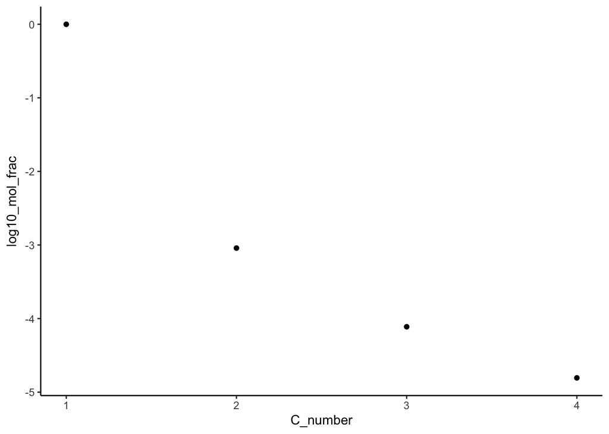

```r
data_ASF_LCHF_mol_frac_longer %>% ggplot(aes(x = C_number, y = log10_mol_frac))+
  geom_point()+
  scale_shape_manual(values = c(1), na.value = 3) +
  theme_classic()
```

## 11.3 Lost City NSHQ14 comparison

```r
data_ASF_LCHF_mol_frac_longer <- data_ASF_LCHF_mol_frac_longer %>% mutate(site = "Lost City") %>% select(C_number, log10_mol_frac, site)
data_ASF_NSHQ14_mol_frac_longer <- data_ASF_NSHQ14_mol_frac_longer_2018 %>% mutate(site = "NSHQ14") %>% select(C_number, log10_mol_frac, site)

data_ASF_NSHQ14_LCHF <- data_ASF_LCHF_mol_frac_longer %>% bind_rows(data_ASF_NSHQ14_mol_frac_longer)

data_ASF_NSHQ14_LCHF
```

| C_number | log10_mol_frac | site |
| --- | --- | --- |
| 1 | -0.0004351635 | Lost City |
| 2 | -3.0416920814 | Lost City |
| 3 | -4.1112539438 | Lost City |
| 4 | -4.8059367913 | Lost City |
| 1 | -0.0005519618 | NSHQ14 |
| 2 | -2.9886826265 | NSHQ14 |
| 3 | -3.9702383800 | NSHQ14 |
| 4 | -4.1425203559 | NSHQ14 |
| 5 | -4.3100382732 | NSHQ14 |
| 6 | -4.8057914182 | NSHQ14 |

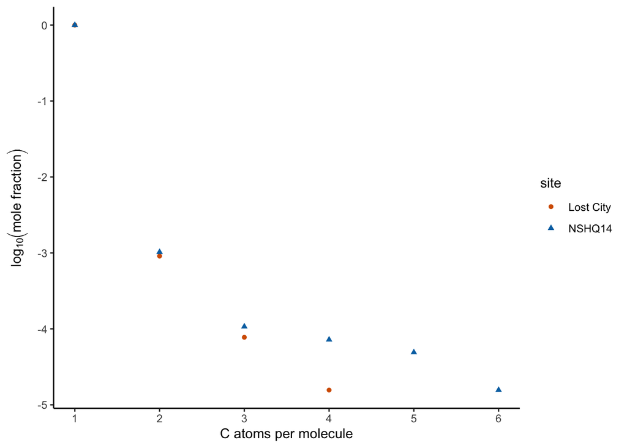

```r
data_ASF_NSHQ14_LCHF_plot <- data_ASF_NSHQ14_LCHF %>% ggplot(aes(x = C_number, y = log10_mol_frac, color = site, shape = site))+
  geom_point()+
  scale_color_manual(values = cbPalette_MWL) +
  scale_x_continuous(name = "C atoms per molecule", n.breaks = 6) +
  scale_y_continuous(name = TeX("log$_{10}\\left($mole fraction$\\right)$")) +
  theme_classic()

data_ASF_NSHQ14_LCHF_plot
```

```r
# generate linear model
model_LCHF_mol_frac_longer = lm(log10_mol_frac ~ C_number,
           data = data_ASF_LCHF_mol_frac_longer %>% filter(C_number > 1))

model_LCHF_mol_frac_longer_int <- coef(model_LCHF_mol_frac_longer)[1] %>% as.numeric()
model_LCHF_mol_frac_longer_slope <- coef(model_LCHF_mol_frac_longer)[2] %>% as.numeric()

# print model summary
summary(model_LCHF_mol_frac_longer)
```

```
##
## Call:
## lm(formula = log10_mol_frac ~ C_number, data = data_ASF_LCHF_mol_frac_longer %>%
##     filter(C_number > 1))
##
## Residuals:
##        1        2        3
##  0.06248 -0.12496  0.06248
##
## Coefficients:
##             Estimate Std. Error t value Pr(>|t|)
## (Intercept)  -1.3399     0.3365  -3.982   0.1566
## C_number     -0.8821     0.1082  -8.151   0.0777 .
## ---
## Signif. codes:  0 '***' 0.001 '**' 0.01 '*' 0.05 '.' 0.1 ' ' 1
##
## Residual standard error: 0.153 on 1 degrees of freedom
## Multiple R-squared:  0.9852, Adjusted R-squared:  0.9703
## F-statistic: 66.44 on 1 and 1 DF,  p-value: 0.07771
```

```r
model_LCHF_mol_frac_longer_int
```

```
## [1] -1.339927
```

```r
model_LCHF_mol_frac_longer_slope
```

```
## [1] -0.8821224
```

Calculate chain-growth probability factor from slope and intercept for C2-C4 region

```r
(alpha_ASF_slope_LCHF <- 10^model_LCHF_mol_frac_longer_slope)
```

```
## [1] 0.131183
```

```r
(alpha_ASF_int_LCHF <- 1 - 10^model_LCHF_mol_frac_longer_int)
```

```
## [1] 0.9542835
```

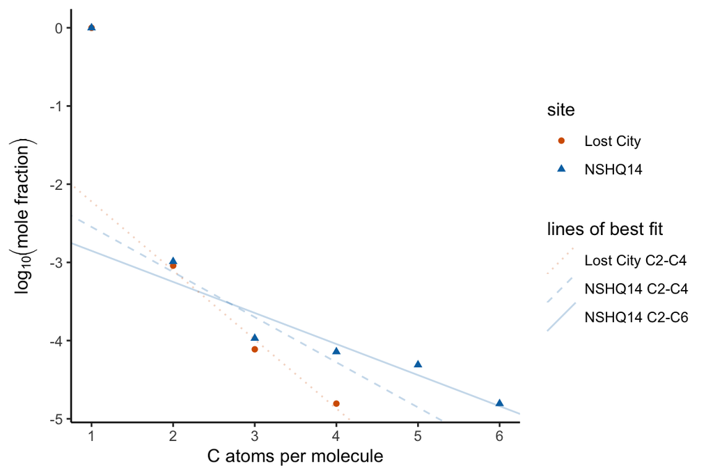

```r
linetype_scale_ASF_fits <- c("solid", "dashed", "dotted")
names(linetype_scale_ASF_fits) <- c("NSHQ14 C2-C6", "NSHQ14 C2-C4", "Lost City C2-C4")


data_ASF_NSHQ14_LCHF_plot +
  geom_abline(aes(intercept = model_NSHQ14_mol_frac_longer_2018_C2_C6_int, slope = model_NSHQ14_mol_frac_longer_2018_C2_C6_slope, linetype = "NSHQ14 C2-C6"), color = cbPalette_MWL[2], alpha = 0.25) +
    geom_abline(aes(intercept = model_NSHQ14_mol_frac_longer_2018_C2_C4_int, slope = model_NSHQ14_mol_frac_longer_2018_C2_C4_slope, linetype="NSHQ14 C2-C4"), color = cbPalette_MWL[2], alpha = 0.25)+
    geom_abline(aes(intercept = model_LCHF_mol_frac_longer_int, slope = model_LCHF_mol_frac_longer_slope, linetype="Lost City C2-C4"), color = cbPalette_MWL[1], alpha = 0.25) +
    scale_linetype_manual(name = "lines of best fit",  values = linetype_scale_ASF_fits)
```